# examples_0529

$$c_{3,4}~=~( 3 \cdot 3 )+( 1 \cdot 0
)+( 5 \cdot 1 )+( 4 \cdot 5 )$$

$$c_{3,4}~=~9+0+5+20$$

$$c_{3,4}~=~34$$

Thus,

$$\begin{bmatrix}
3 & 3 & 1 & 6\\
2 & 4 & 4 & 4\\
3 & 1 & 5 & 4
\end{bmatrix} \cdot \begin{bmatrix}
0 & 6 & 2 & 3 & 3\\
0 & 2 & 0 & 0 & 0\\
3 & 2 & 2 & 1 & 5\\
0 & 3 & 4 & 5 & 3
\end{bmatrix} ~=~ \begin{bmatrix}
3 & 44 & 32 & 40 & 32\\
12 & 40 & 28 & 30 & 38\\
15 & 42 & 32 & 34 & 46
\end{bmatrix}$$

Let matrices $A$ and $B$ be defined below.

$$A = \begin{bmatrix}
0 & 6 & 1 & 0\\
5 & 1 & 0 & 3\\
1 & 6 & 5 & 5
\end{bmatrix}$$
$$B = \begin{bmatrix}
5 & 2 & 5 & 3 & 6\\
0 & 2 & 0 & 5 & 1\\
6 & 0 & 2 & 0 & 1\\
0 & 2 & 3 & 3 & 3
\end{bmatrix}$$

A third matrix, $C$, is equal to the [product](https://en.wikipedia.org/wiki/Matrix_multiplication) $AB$. A student set up a diagram to help find the product; they are missing a single element in $C$, element $c_{1,3}$.

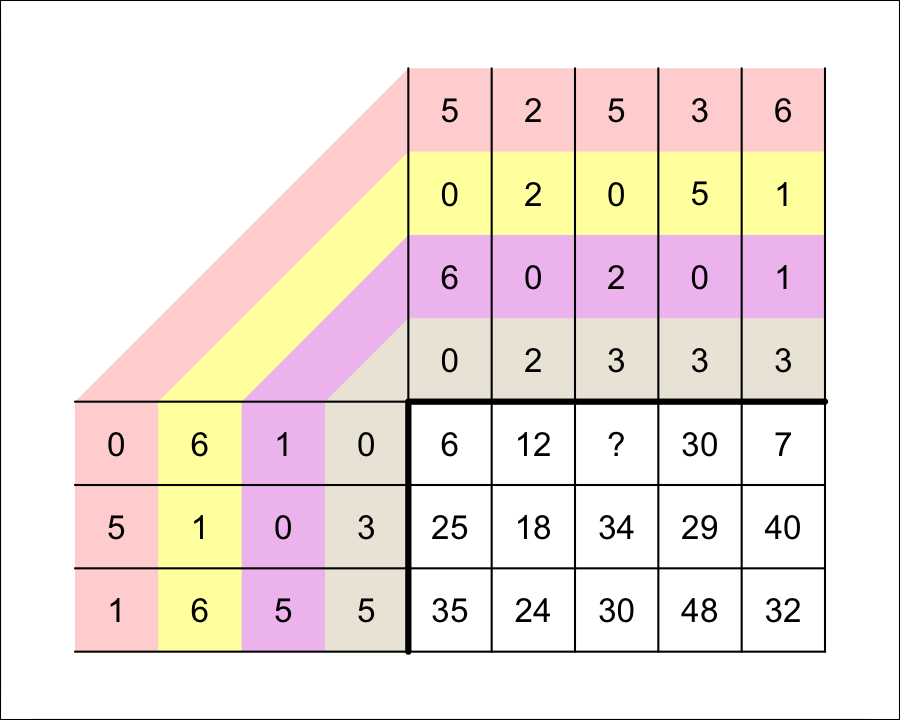

What is $c_{1,3}$?

To find $c_{1,3}$, you use row 1 from matrix $A$ and column 3 from matrix $B$.

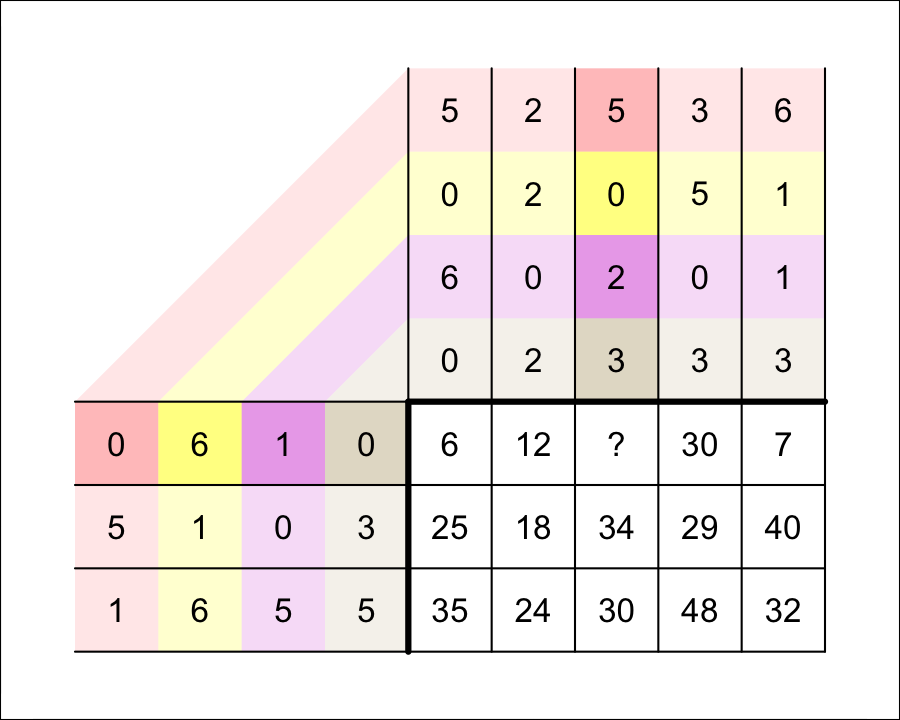

You multiply corresponding elements and sum those products.

$$c_{1,3}~=~( 0 \cdot 5 )+( 6 \cdot 0
)+( 1 \cdot 2 )+( 0 \cdot 3 )$$

$$c_{1,3}~=~0+0+2+0$$

$$c_{1,3}~=~2$$

Thus,

$$\begin{bmatrix}
0 & 6 & 1 & 0\\
5 & 1 & 0 & 3\\
1 & 6 & 5 & 5
\end{bmatrix} \cdot \begin{bmatrix}
5 & 2 & 5 & 3 & 6\\
0 & 2 & 0 & 5 & 1\\
6 & 0 & 2 & 0 & 1\\
0 & 2 & 3 & 3 & 3
\end{bmatrix} ~=~ \begin{bmatrix}
6 & 12 & 2 & 30 & 7\\
25 & 18 & 34 & 29 & 40\\
35 & 24 & 30 & 48 & 32
\end{bmatrix}$$

Let matrices $A$ and $B$ be defined below.

$$A = \begin{bmatrix}
2 & 0 & 6 & 2\\
3 & 0 & 0 & 2\\
4 & 0 & 4 & 2
\end{bmatrix}$$
$$B = \begin{bmatrix}
1 & 3 & 5 & 6 & 5\\
2 & 6 & 4 & 1 & 0\\
4 & 6 & 2 & 0 & 4\\
4 & 4 & 2 & 5 & 6
\end{bmatrix}$$

A third matrix, $C$, is equal to the [product](https://en.wikipedia.org/wiki/Matrix_multiplication) $AB$. A student set up a diagram to help find the product; they are missing a single element in $C$, element $c_{3,1}$.

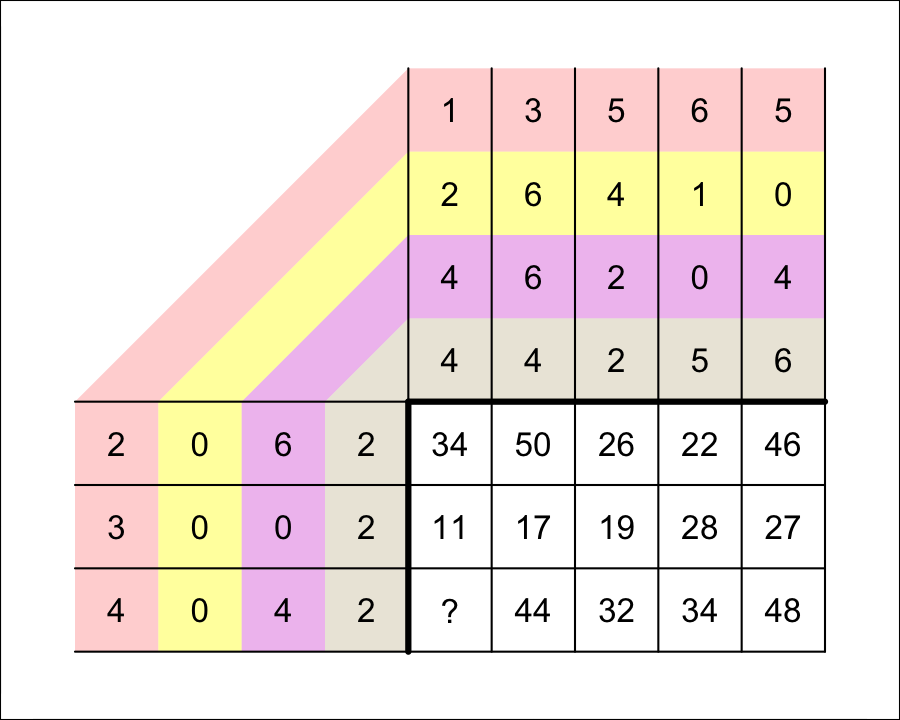

What is $c_{3,1}$?

To find $c_{3,1}$, you use row 3 from matrix $A$ and column 1 from matrix $B$.

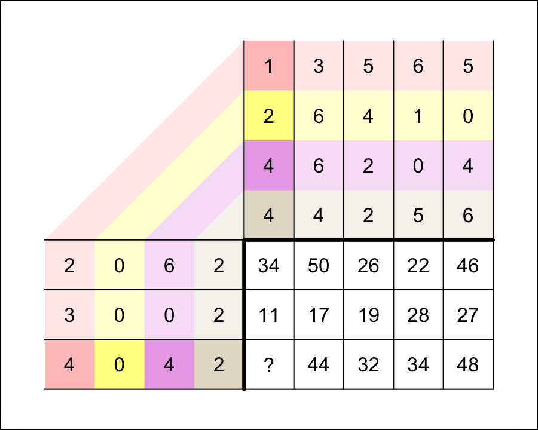

You multiply corresponding elements and sum those products.

$$c_{3,1}~=~( 4 \cdot 1 )+( 0 \cdot 2
)+( 4 \cdot 4 )+( 2 \cdot 4 )$$

$$c_{3,1}~=~4+0+16+8$$

$$c_{3,1}~=~28$$

Thus,

$$\begin{bmatrix}
2 & 0 & 6 & 2\\
3 & 0 & 0 & 2\\
4 & 0 & 4 & 2
\end{bmatrix} \cdot \begin{bmatrix}
1 & 3 & 5 & 6 & 5\\
2 & 6 & 4 & 1 & 0\\
4 & 6 & 2 & 0 & 4\\
4 & 4 & 2 & 5 & 6
\end{bmatrix} ~=~ \begin{bmatrix}
34 & 50 & 26 & 22 & 46\\
11 & 17 & 19 & 28 & 27\\
28 & 44 & 32 & 34 & 48
\end{bmatrix}$$

Let matrices $A$ and $B$ be defined below.

$$A = \begin{bmatrix}
1 & 4 & 6 & 4\\
0 & 5 & 6 & 3\\
5 & 0 & 0 & 2
\end{bmatrix}$$
$$B = \begin{bmatrix}
6 & 1 & 1 & 4 & 3\\
0 & 1 & 5 & 3 & 4\\
5 & 3 & 3 & 1 & 5\\
4 & 0 & 5 & 2 & 6
\end{bmatrix}$$

A third matrix, $C$, is equal to the [product](https://en.wikipedia.org/wiki/Matrix_multiplication) $AB$. A student set up a diagram to help find the product; they are missing a single element in $C$, element $c_{2,2}$.

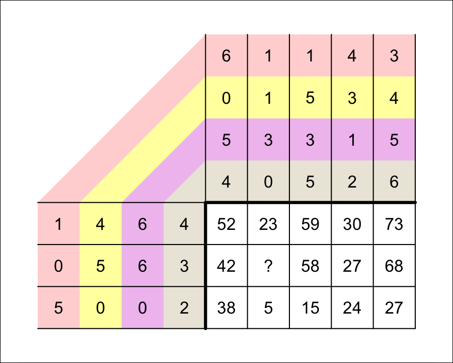

What is $c_{2,2}$?

To find $c_{2,2}$, you use row 2 from matrix $A$ and column 2 from matrix $B$.

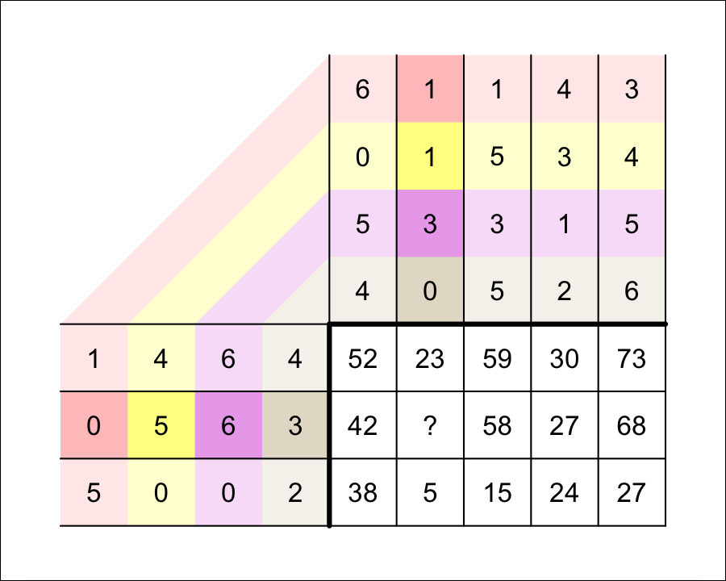

You multiply corresponding elements and sum those products.

$$c_{2,2}~=~( 0 \cdot 1 )+( 5 \cdot 1
)+( 6 \cdot 3 )+( 3 \cdot 0 )$$

$$c_{2,2}~=~0+5+18+0$$

$$c_{2,2}~=~23$$

Thus,

$$\begin{bmatrix}
1 & 4 & 6 & 4\\
0 & 5 & 6 & 3\\
5 & 0 & 0 & 2
\end{bmatrix} \cdot \begin{bmatrix}
6 & 1 & 1 & 4 & 3\\
0 & 1 & 5 & 3 & 4\\
5 & 3 & 3 & 1 & 5\\
4 & 0 & 5 & 2 & 6
\end{bmatrix} ~=~ \begin{bmatrix}
52 & 23 & 59 & 30 & 73\\
42 & 23 & 58 & 27 & 68\\
38 & 5 & 15 & 24 & 27
\end{bmatrix}$$

Let matrices $A$ and $B$ be defined below.

$$A = \begin{bmatrix}
2 & 3 & 0 & 6\\
1 & 4 & 2 & 5\\
1 & 0 & 1 & 4
\end{bmatrix}$$
$$B = \begin{bmatrix}
3 & 0 & 3 & 2 & 5\\
4 & 0 & 4 & 3 & 3\\
3 & 2 & 4 & 4 & 2\\
0 & 1 & 5 & 4 & 4
\end{bmatrix}$$

A third matrix, $C$, is equal to the [product](https://en.wikipedia.org/wiki/Matrix_multiplication) $AB$. A student set up a diagram to help find the product; they are missing a single element in $C$, element $c_{2,2}$.

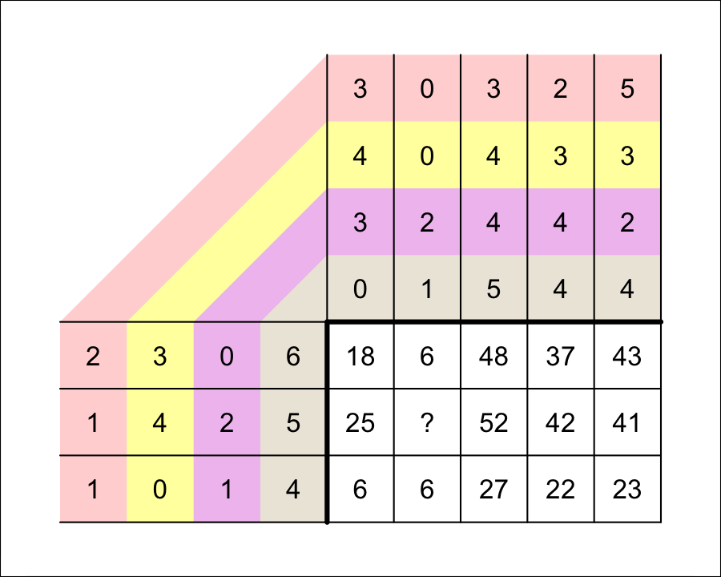

What is $c_{2,2}$?

To find $c_{2,2}$, you use row 2 from matrix $A$ and column 2 from matrix $B$.

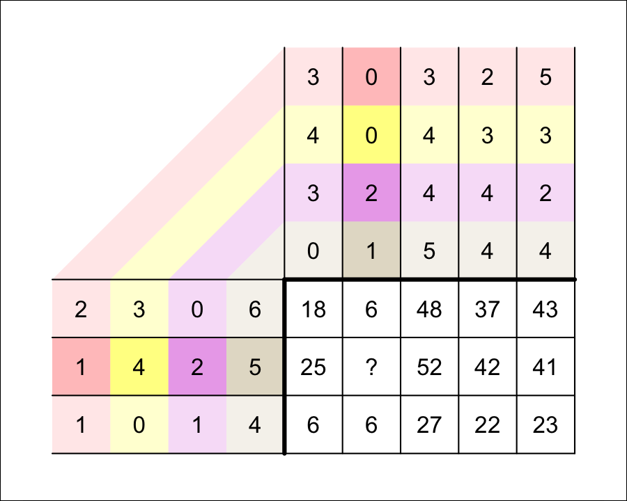

You multiply corresponding elements and sum those products.

$$c_{2,2}~=~( 1 \cdot 0 )+( 4 \cdot 0
)+( 2 \cdot 2 )+( 5 \cdot 1 )$$

$$c_{2,2}~=~0+0+4+5$$

$$c_{2,2}~=~9$$

Thus,

$$\begin{bmatrix}
2 & 3 & 0 & 6\\
1 & 4 & 2 & 5\\
1 & 0 & 1 & 4
\end{bmatrix} \cdot \begin{bmatrix}
3 & 0 & 3 & 2 & 5\\
4 & 0 & 4 & 3 & 3\\
3 & 2 & 4 & 4 & 2\\
0 & 1 & 5 & 4 & 4
\end{bmatrix} ~=~ \begin{bmatrix}
18 & 6 & 48 & 37 & 43\\
25 & 9 & 52 & 42 & 41\\
6 & 6 & 27 & 22 & 23
\end{bmatrix}$$

Let matrices $A$ and $B$ be defined below.

$$A = \begin{bmatrix}
3 & 1 & 5 & 1\\
4 & 6 & 6 & 3\\
3 & 1 & 6 & 2
\end{bmatrix}$$
$$B = \begin{bmatrix}
5 & 1 & 5 & 5 & 6\\
1 & 1 & 0 & 4 & 6\\
4 & 2 & 1 & 0 & 6\\
2 & 5 & 3 & 4 & 1
\end{bmatrix}$$

A third matrix, $C$, is equal to the [product](https://en.wikipedia.org/wiki/Matrix_multiplication) $AB$. A student set up a diagram to help find the product; they are missing a single element in $C$, element $c_{3,2}$.

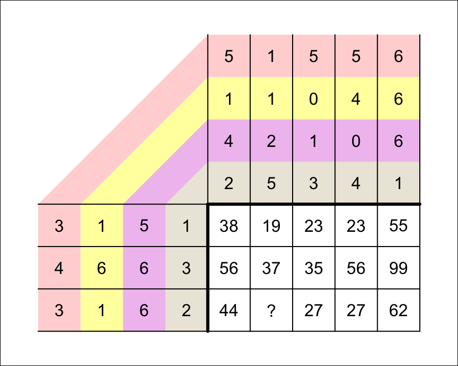

What is $c_{3,2}$?

To find $c_{3,2}$, you use row 3 from matrix $A$ and column 2 from matrix $B$.

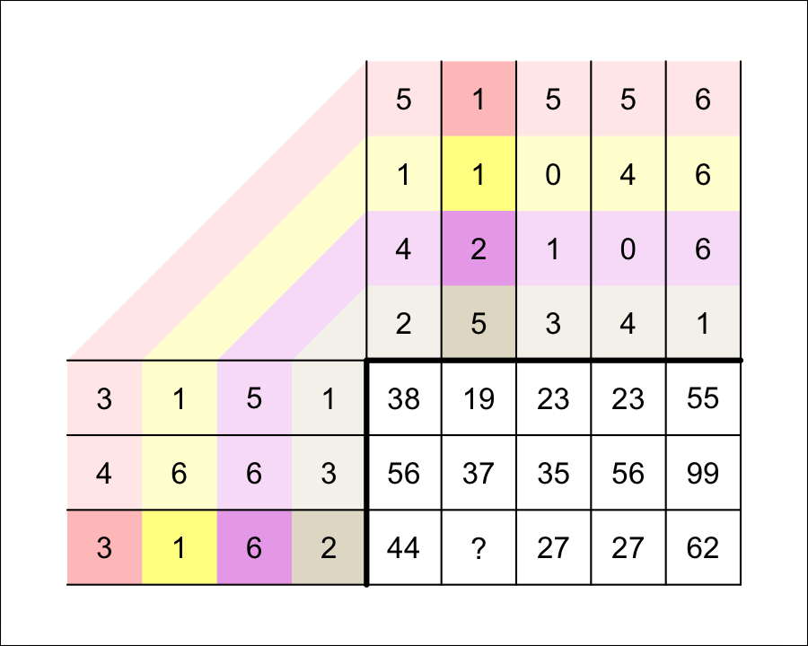

You multiply corresponding elements and sum those products.

$$c_{3,2}~=~( 3 \cdot 1 )+( 1 \cdot 1
)+( 6 \cdot 2 )+( 2 \cdot 5 )$$

$$c_{3,2}~=~3+1+12+10$$

$$c_{3,2}~=~26$$

Thus,

$$\begin{bmatrix}
3 & 1 & 5 & 1\\
4 & 6 & 6 & 3\\
3 & 1 & 6 & 2
\end{bmatrix} \cdot \begin{bmatrix}
5 & 1 & 5 & 5 & 6\\
1 & 1 & 0 & 4 & 6\\
4 & 2 & 1 & 0 & 6\\
2 & 5 & 3 & 4 & 1
\end{bmatrix} ~=~ \begin{bmatrix}
38 & 19 & 23 & 23 & 55\\
56 & 37 & 35 & 56 & 99\\
44 & 26 & 27 & 27 & 62
\end{bmatrix}$$

Let matrices $A$ and $B$ be defined below.

$$A = \begin{bmatrix}
2 & 3 & 6 & 4\\
3 & 2 & 6 & 5\\
6 & 1 & 1 & 6
\end{bmatrix}$$
$$B = \begin{bmatrix}
1 & 5 & 0 & 0 & 5\\
5 & 3 & 5 & 3 & 1\\
5 & 1 & 0 & 2 & 0\\
3 & 4 & 5 & 5 & 2
\end{bmatrix}$$

A third matrix, $C$, is equal to the [product](https://en.wikipedia.org/wiki/Matrix_multiplication) $AB$. A student set up a diagram to help find the product; they are missing a single element in $C$, element $c_{2,4}$.

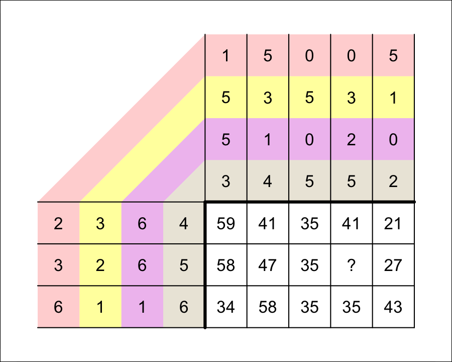

What is $c_{2,4}$?

To find $c_{2,4}$, you use row 2 from matrix $A$ and column 4 from matrix $B$.

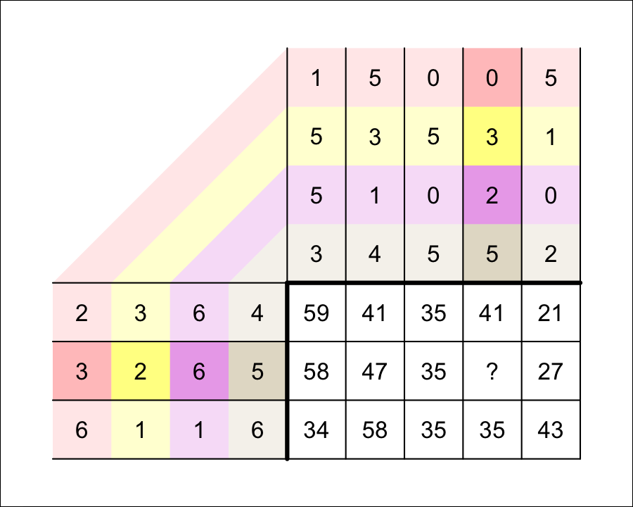

You multiply corresponding elements and sum those products.

$$c_{2,4}~=~( 3 \cdot 0 )+( 2 \cdot 3
)+( 6 \cdot 2 )+( 5 \cdot 5 )$$

$$c_{2,4}~=~0+6+12+25$$

$$c_{2,4}~=~43$$

Thus,

$$\begin{bmatrix}
2 & 3 & 6 & 4\\
3 & 2 & 6 & 5\\
6 & 1 & 1 & 6
\end{bmatrix} \cdot \begin{bmatrix}
1 & 5 & 0 & 0 & 5\\
5 & 3 & 5 & 3 & 1\\
5 & 1 & 0 & 2 & 0\\
3 & 4 & 5 & 5 & 2
\end{bmatrix} ~=~ \begin{bmatrix}
59 & 41 & 35 & 41 & 21\\
58 & 47 & 35 & 43 & 27\\
34 & 58 & 35 & 35 & 43
\end{bmatrix}$$

Let matrices $A$ and $B$ be defined below.

$$A = \begin{bmatrix}
2 & 4 & 3 & 3\\
3 & 5 & 2 & 3\\
4 & 1 & 2 & 4
\end{bmatrix}$$
$$B = \begin{bmatrix}
0 & 0 & 2 & 1 & 5\\
5 & 1 & 3 & 6 & 6\\
6 & 0 & 1 & 1 & 1\\
0 & 3 & 1 & 0 & 5
\end{bmatrix}$$

A third matrix, $C$, is equal to the [product](https://en.wikipedia.org/wiki/Matrix_multiplication) $AB$. A student set up a diagram to help find the product; they are missing a single element in $C$, element $c_{1,3}$.

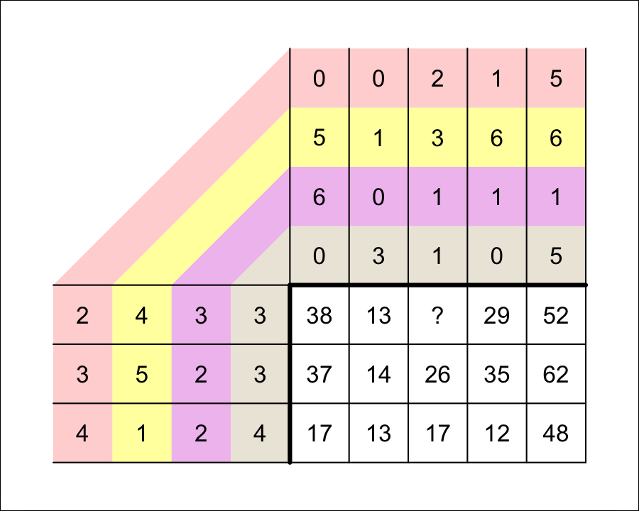

What is $c_{1,3}$?

To find $c_{1,3}$, you use row 1 from matrix $A$ and column 3 from matrix $B$.

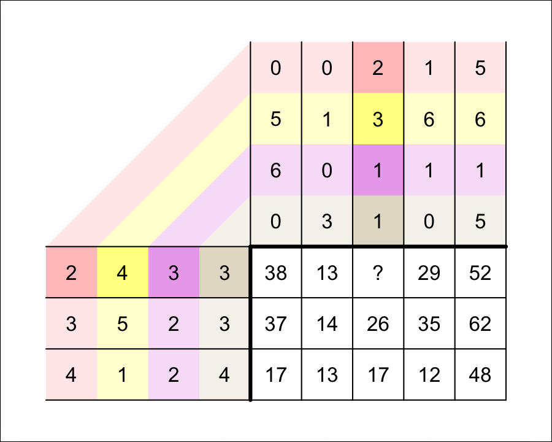

You multiply corresponding elements and sum those products.

$$c_{1,3}~=~( 2 \cdot 2 )+( 4 \cdot 3
)+( 3 \cdot 1 )+( 3 \cdot 1 )$$

$$c_{1,3}~=~4+12+3+3$$

$$c_{1,3}~=~22$$

Thus,

$$\begin{bmatrix}
2 & 4 & 3 & 3\\
3 & 5 & 2 & 3\\
4 & 1 & 2 & 4
\end{bmatrix} \cdot \begin{bmatrix}
0 & 0 & 2 & 1 & 5\\
5 & 1 & 3 & 6 & 6\\
6 & 0 & 1 & 1 & 1\\
0 & 3 & 1 & 0 & 5
\end{bmatrix} ~=~ \begin{bmatrix}
38 & 13 & 22 & 29 & 52\\
37 & 14 & 26 & 35 & 62\\
17 & 13 & 17 & 12 & 48
\end{bmatrix}$$

Let matrices $A$ and $B$ be defined below.

$$A = \begin{bmatrix}
3 & 0 & 3 & 1\\
2 & 2 & 6 & 1\\
5 & 2 & 2 & 0
\end{bmatrix}$$
$$B = \begin{bmatrix}
2 & 0 & 2 & 1 & 0\\
1 & 5 & 3 & 5 & 2\\
1 & 1 & 2 & 0 & 2\\
0 & 4 & 6 & 1 & 4
\end{bmatrix}$$

A third matrix, $C$, is equal to the [product](https://en.wikipedia.org/wiki/Matrix_multiplication) $AB$. A student set up a diagram to help find the product; they are missing a single element in $C$, element $c_{3,5}$.

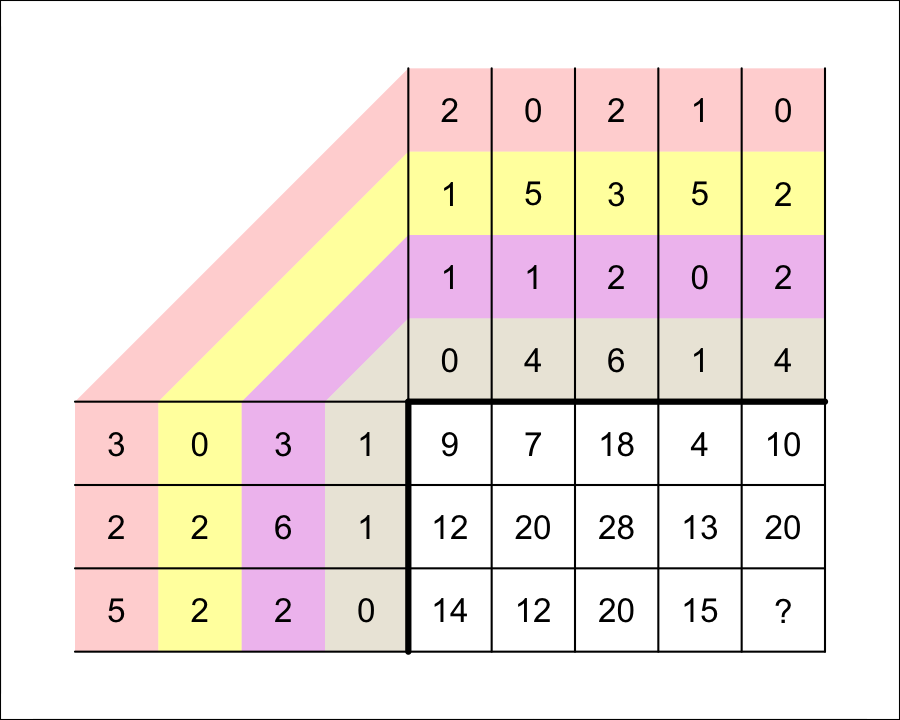

What is $c_{3,5}$?

To find $c_{3,5}$, you use row 3 from matrix $A$ and column 5 from matrix $B$.

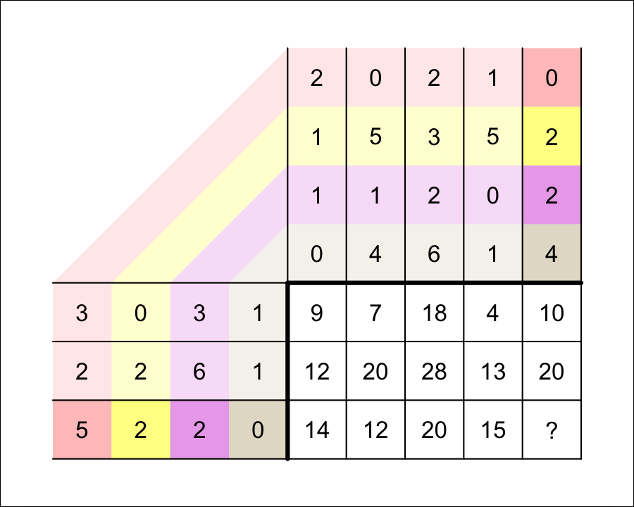

You multiply corresponding elements and sum those products.

$$c_{3,5}~=~( 5 \cdot 0 )+( 2 \cdot 2
)+( 2 \cdot 2 )+( 0 \cdot 4 )$$

$$c_{3,5}~=~0+4+4+0$$

$$c_{3,5}~=~8$$

Thus,

$$\begin{bmatrix}
3 & 0 & 3 & 1\\
2 & 2 & 6 & 1\\
5 & 2 & 2 & 0
\end{bmatrix} \cdot \begin{bmatrix}
2 & 0 & 2 & 1 & 0\\
1 & 5 & 3 & 5 & 2\\
1 & 1 & 2 & 0 & 2\\
0 & 4 & 6 & 1 & 4
\end{bmatrix} ~=~ \begin{bmatrix}
9 & 7 & 18 & 4 & 10\\
12 & 20 & 28 & 13 & 20\\
14 & 12 & 20 & 15 & 8
\end{bmatrix}$$

Let matrices $A$ and $B$ be defined below.

$$A = \begin{bmatrix}
5 & 1 & 6 & 4\\
0 & 0 & 2 & 6\\
6 & 4 & 4 & 2
\end{bmatrix}$$
$$B = \begin{bmatrix}
3 & 5 & 3 & 6 & 5\\
0 & 4 & 5 & 2 & 4\\
3 & 3 & 3 & 0 & 6\\
1 & 5 & 1 & 1 & 0
\end{bmatrix}$$

A third matrix, $C$, is equal to the [product](https://en.wikipedia.org/wiki/Matrix_multiplication) $AB$. A student set up a diagram to help find the product; they are missing a single element in $C$, element $c_{2,1}$.

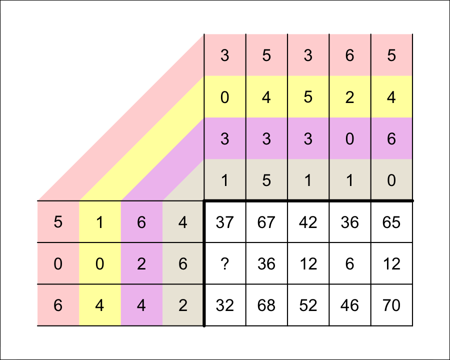

What is $c_{2,1}$?

To find $c_{2,1}$, you use row 2 from matrix $A$ and column 1 from matrix $B$.

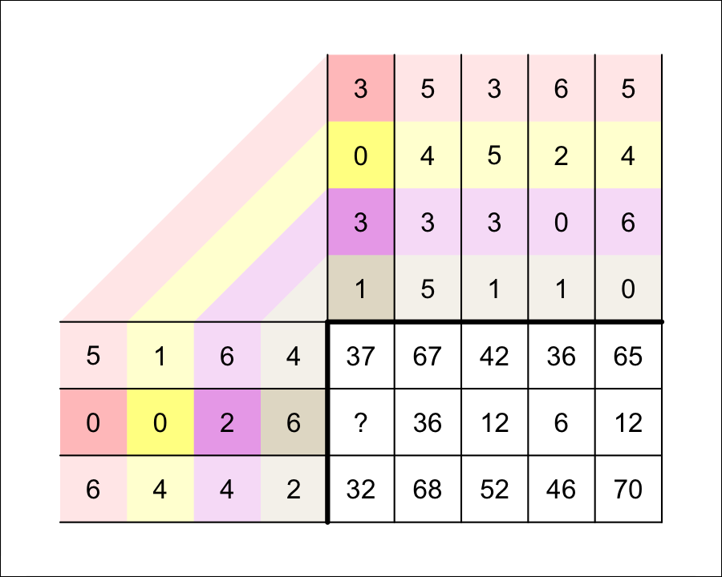

You multiply corresponding elements and sum those products.

$$c_{2,1}~=~( 0 \cdot 3 )+( 0 \cdot 0
)+( 2 \cdot 3 )+( 6 \cdot 1 )$$

$$c_{2,1}~=~0+0+6+6$$

$$c_{2,1}~=~12$$

Thus,

$$\begin{bmatrix}
5 & 1 & 6 & 4\\
0 & 0 & 2 & 6\\
6 & 4 & 4 & 2
\end{bmatrix} \cdot \begin{bmatrix}
3 & 5 & 3 & 6 & 5\\
0 & 4 & 5 & 2 & 4\\
3 & 3 & 3 & 0 & 6\\
1 & 5 & 1 & 1 & 0
\end{bmatrix} ~=~ \begin{bmatrix}
37 & 67 & 42 & 36 & 65\\
12 & 36 & 12 & 6 & 12\\
32 & 68 & 52 & 46 & 70
\end{bmatrix}$$

Let matrices $A$ and $B$ be defined below.

$$A = \begin{bmatrix}
2 & 2 & 2 & 1\\
1 & 5 & 0 & 3\\
5 & 2 & 0 & 5
\end{bmatrix}$$
$$B = \begin{bmatrix}
1 & 5 & 0 & 0 & 0\\
1 & 3 & 3 & 6 & 1\\
1 & 6 & 6 & 5 & 5\\
1 & 0 & 4 & 3 & 6
\end{bmatrix}$$

A third matrix, $C$, is equal to the [product](https://en.wikipedia.org/wiki/Matrix_multiplication) $AB$. A student set up a diagram to help find the product; they are missing a single element in $C$, element $c_{2,3}$.

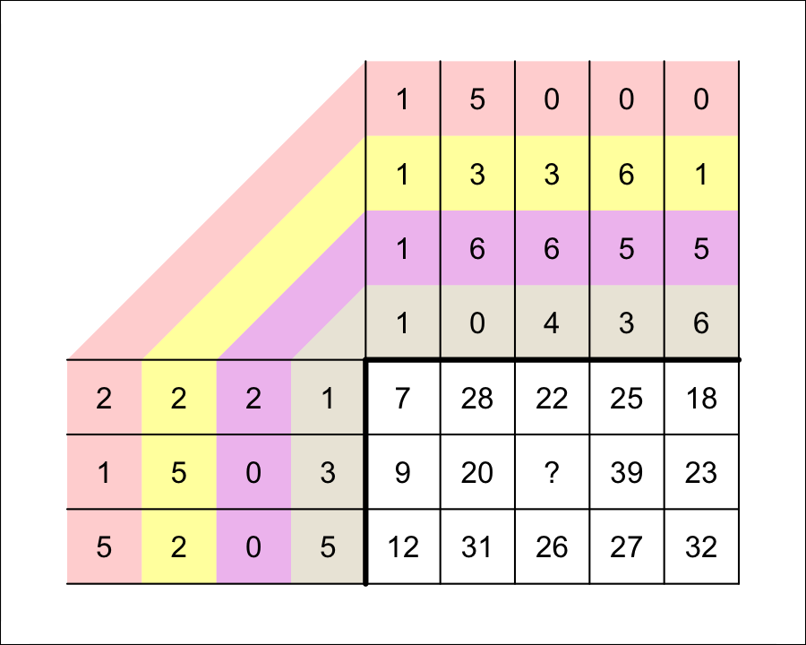

What is $c_{2,3}$?

To find $c_{2,3}$, you use row 2 from matrix $A$ and column 3 from matrix $B$.

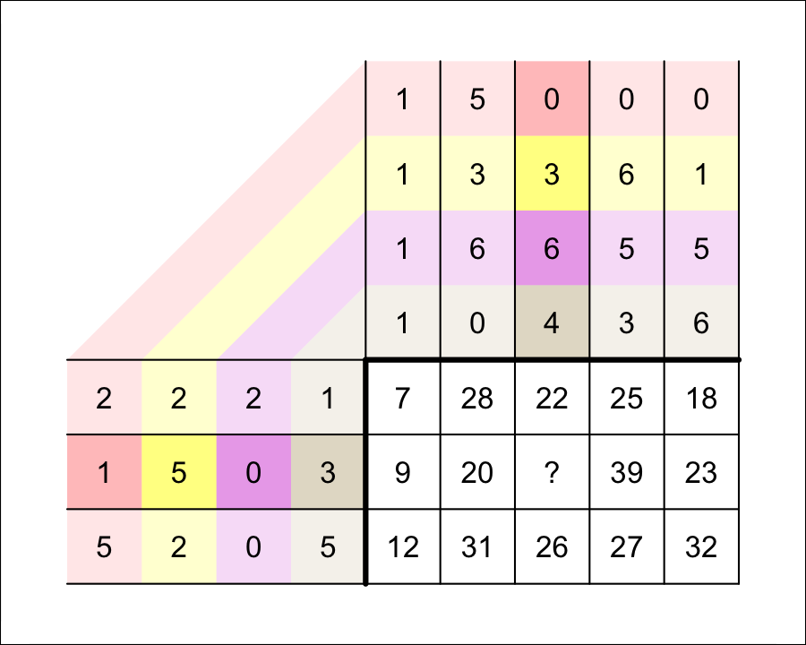

You multiply corresponding elements and sum those products.

$$c_{2,3}~=~( 1 \cdot 0 )+( 5 \cdot 3
)+( 0 \cdot 6 )+( 3 \cdot 4 )$$

$$c_{2,3}~=~0+15+0+12$$

$$c_{2,3}~=~27$$

Thus,

$$\begin{bmatrix}
2 & 2 & 2 & 1\\
1 & 5 & 0 & 3\\
5 & 2 & 0 & 5
\end{bmatrix} \cdot \begin{bmatrix}
1 & 5 & 0 & 0 & 0\\
1 & 3 & 3 & 6 & 1\\
1 & 6 & 6 & 5 & 5\\
1 & 0 & 4 & 3 & 6
\end{bmatrix} ~=~ \begin{bmatrix}
7 & 28 & 22 & 25 & 18\\
9 & 20 & 27 & 39 & 23\\
12 & 31 & 26 & 27 & 32
\end{bmatrix}$$

Let matrices $A$ and $B$ be defined below.

$$A = \begin{bmatrix}
3 & 3 & 6 & 0\\
5 & 0 & 0 & 1\\
4 & 1 & 5 & 2
\end{bmatrix}$$
$$B = \begin{bmatrix}
2 & 5 & 6 & 3 & 2\\
0 & 2 & 0 & 5 & 5\\
5 & 3 & 5 & 0 & 2\\
4 & 1 & 0 & 2 & 1
\end{bmatrix}$$

A third matrix, $C$, is equal to the [product](https://en.wikipedia.org/wiki/Matrix_multiplication) $AB$. A student set up a diagram to help find the product; they are missing a single element in $C$, element $c_{1,5}$.

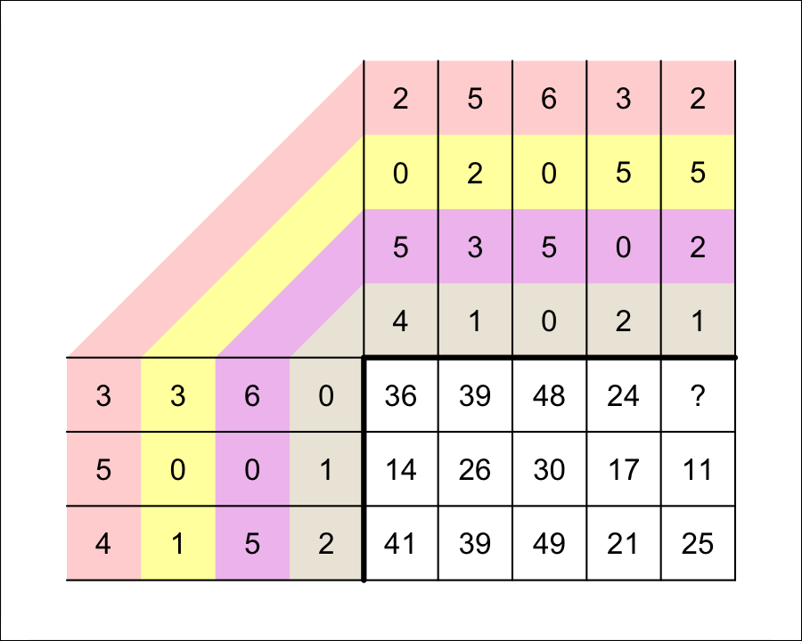

What is $c_{1,5}$?

To find $c_{1,5}$, you use row 1 from matrix $A$ and column 5 from matrix $B$.

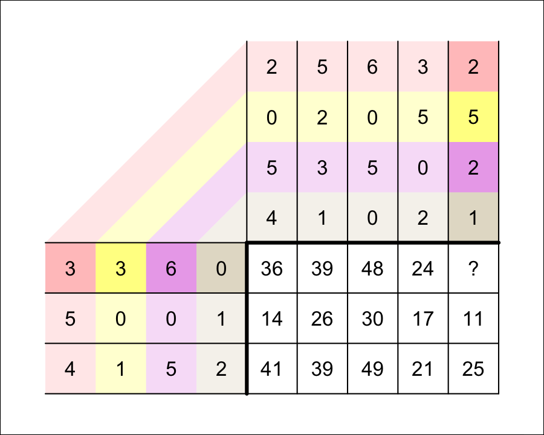

You multiply corresponding elements and sum those products.

$$c_{1,5}~=~( 3 \cdot 2 )+( 3 \cdot 5
)+( 6 \cdot 2 )+( 0 \cdot 1 )$$

$$c_{1,5}~=~6+15+12+0$$

$$c_{1,5}~=~33$$

Thus,

$$\begin{bmatrix}
3 & 3 & 6 & 0\\
5 & 0 & 0 & 1\\
4 & 1 & 5 & 2
\end{bmatrix} \cdot \begin{bmatrix}
2 & 5 & 6 & 3 & 2\\
0 & 2 & 0 & 5 & 5\\
5 & 3 & 5 & 0 & 2\\
4 & 1 & 0 & 2 & 1
\end{bmatrix} ~=~ \begin{bmatrix}
36 & 39 & 48 & 24 & 33\\
14 & 26 & 30 & 17 & 11\\
41 & 39 & 49 & 21 & 25
\end{bmatrix}$$

Let matrices $A$ and $B$ be defined below.

$$A = \begin{bmatrix}
5 & 3 & 1 & 4\\
3 & 0 & 2 & 6\\
3 & 3 & 5 & 1
\end{bmatrix}$$
$$B = \begin{bmatrix}
4 & 3 & 5 & 6 & 6\\
3 & 2 & 6 & 3 & 0\\
5 & 0 & 2 & 3 & 4\\
1 & 0 & 1 & 2 & 5
\end{bmatrix}$$

A third matrix, $C$, is equal to the [product](https://en.wikipedia.org/wiki/Matrix_multiplication) $AB$. A student set up a diagram to help find the product; they are missing a single element in $C$, element $c_{3,3}$.

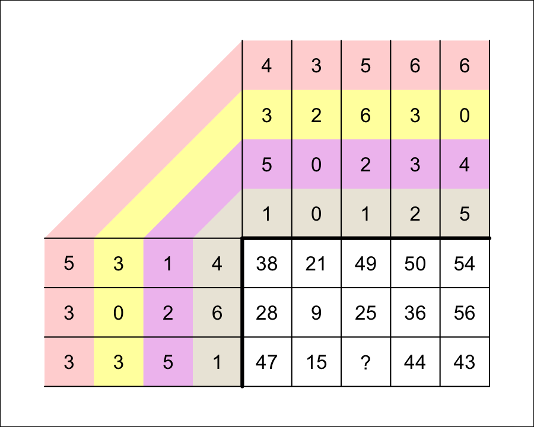

What is $c_{3,3}$?

To find $c_{3,3}$, you use row 3 from matrix $A$ and column 3 from matrix $B$.

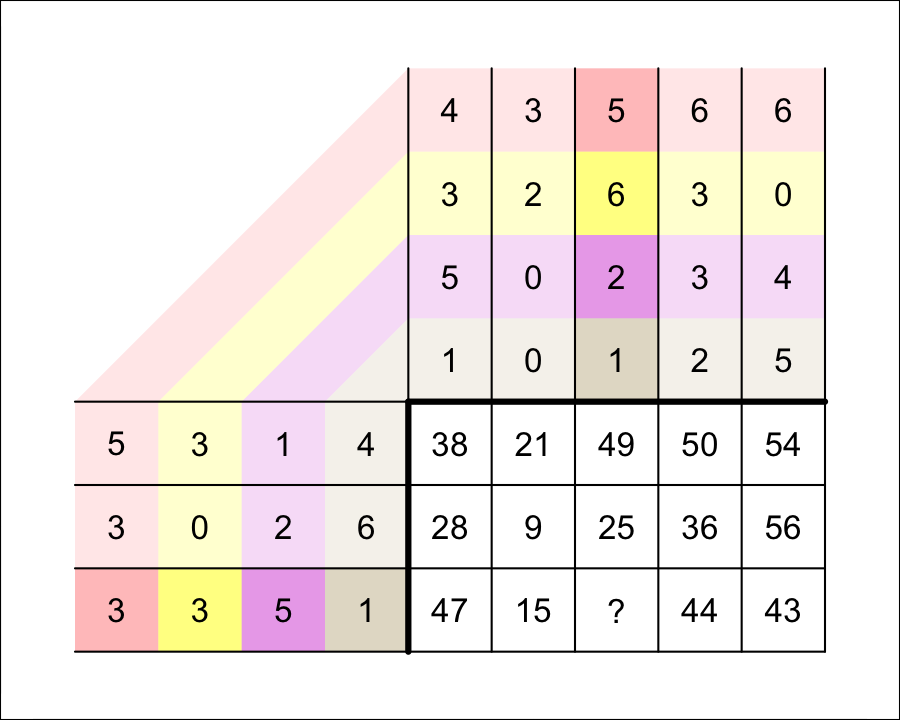

You multiply corresponding elements and sum those products.

$$c_{3,3}~=~( 3 \cdot 5 )+( 3 \cdot 6
)+( 5 \cdot 2 )+( 1 \cdot 1 )$$

$$c_{3,3}~=~15+18+10+1$$

$$c_{3,3}~=~44$$

Thus,

$$\begin{bmatrix}
5 & 3 & 1 & 4\\
3 & 0 & 2 & 6\\
3 & 3 & 5 & 1
\end{bmatrix} \cdot \begin{bmatrix}
4 & 3 & 5 & 6 & 6\\
3 & 2 & 6 & 3 & 0\\
5 & 0 & 2 & 3 & 4\\
1 & 0 & 1 & 2 & 5
\end{bmatrix} ~=~ \begin{bmatrix}
38 & 21 & 49 & 50 & 54\\
28 & 9 & 25 & 36 & 56\\
47 & 15 & 44 & 44 & 43
\end{bmatrix}$$

Let matrices $A$ and $B$ be defined below.

$$A = \begin{bmatrix}
2 & 6 & 0 & 4\\
5 & 6 & 6 & 2\\
3 & 1 & 5 & 1
\end{bmatrix}$$
$$B = \begin{bmatrix}
1 & 0 & 4 & 2 & 4\\
4 & 5 & 1 & 6 & 5\\
3 & 0 & 6 & 6 & 0\\
0 & 4 & 5 & 3 & 1
\end{bmatrix}$$

A third matrix, $C$, is equal to the [product](https://en.wikipedia.org/wiki/Matrix_multiplication) $AB$. A student set up a diagram to help find the product; they are missing a single element in $C$, element $c_{3,4}$.

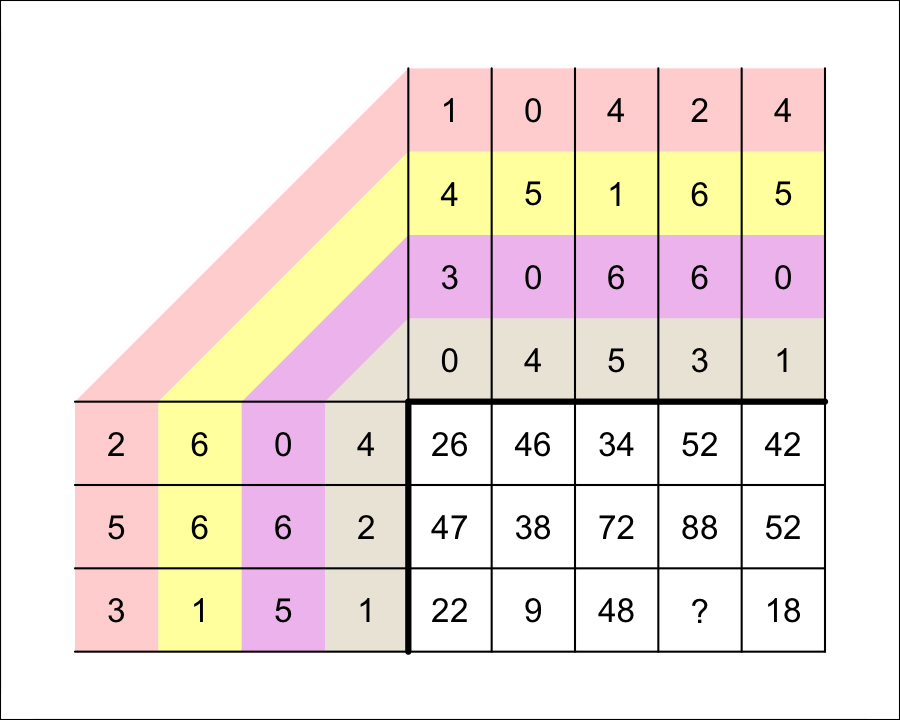

What is $c_{3,4}$?

To find $c_{3,4}$, you use row 3 from matrix $A$ and column 4 from matrix $B$.

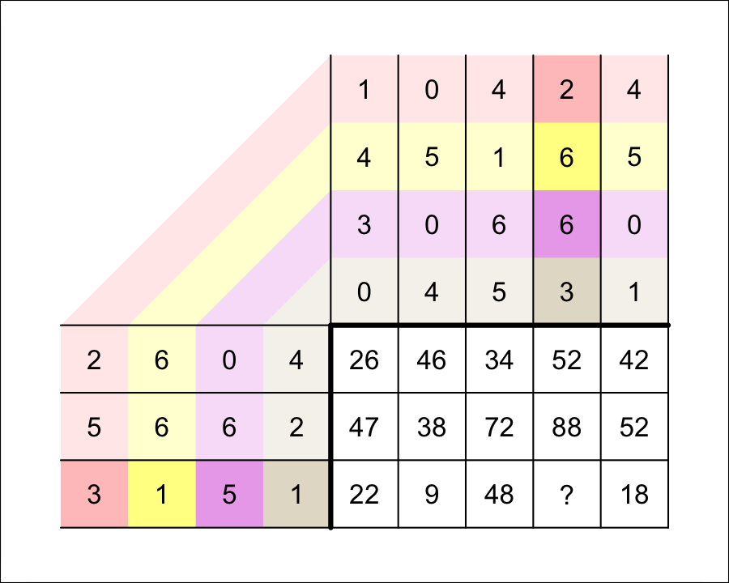

You multiply corresponding elements and sum those products.

$$c_{3,4}~=~( 3 \cdot 2 )+( 1 \cdot 6
)+( 5 \cdot 6 )+( 1 \cdot 3 )$$

$$c_{3,4}~=~6+6+30+3$$

$$c_{3,4}~=~45$$

Thus,

$$\begin{bmatrix}
2 & 6 & 0 & 4\\
5 & 6 & 6 & 2\\
3 & 1 & 5 & 1
\end{bmatrix} \cdot \begin{bmatrix}
1 & 0 & 4 & 2 & 4\\
4 & 5 & 1 & 6 & 5\\
3 & 0 & 6 & 6 & 0\\
0 & 4 & 5 & 3 & 1
\end{bmatrix} ~=~ \begin{bmatrix}
26 & 46 & 34 & 52 & 42\\
47 & 38 & 72 & 88 & 52\\
22 & 9 & 48 & 45 & 18
\end{bmatrix}$$

Let matrices $A$ and $B$ be defined below.

$$A = \begin{bmatrix}
1 & 0 & 3 & 6\\
1 & 5 & 0 & 4\\
2 & 3 & 0 & 4
\end{bmatrix}$$
$$B = \begin{bmatrix}
0 & 0 & 3 & 0 & 1\\
4 & 5 & 3 & 6 & 4\\
5 & 6 & 1 & 1 & 3\\
3 & 6 & 0 & 1 & 1
\end{bmatrix}$$

A third matrix, $C$, is equal to the [product](https://en.wikipedia.org/wiki/Matrix_multiplication) $AB$. A student set up a diagram to help find the product; they are missing a single element in $C$, element $c_{3,5}$.

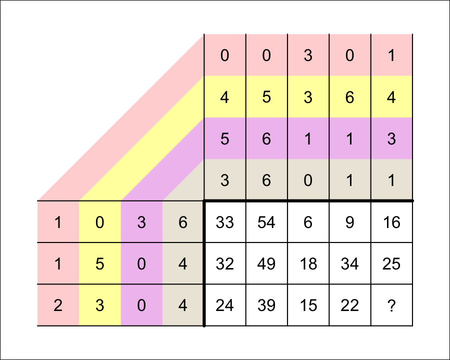

What is $c_{3,5}$?

To find $c_{3,5}$, you use row 3 from matrix $A$ and column 5 from matrix $B$.

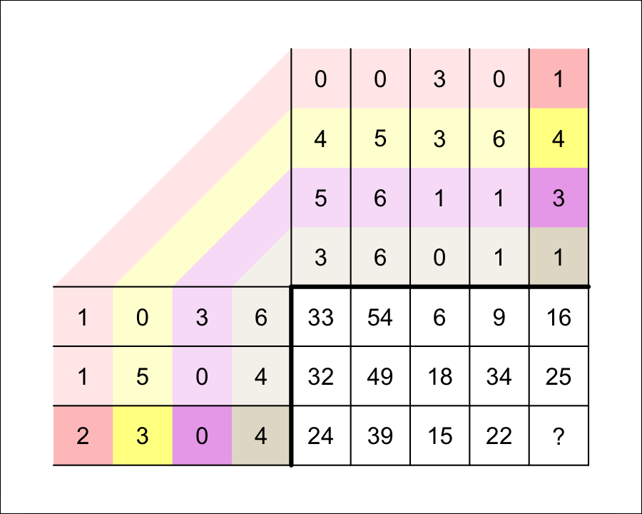

You multiply corresponding elements and sum those products.

$$c_{3,5}~=~( 2 \cdot 1 )+( 3 \cdot 4
)+( 0 \cdot 3 )+( 4 \cdot 1 )$$

$$c_{3,5}~=~2+12+0+4$$

$$c_{3,5}~=~18$$

Thus,

$$\begin{bmatrix}
1 & 0 & 3 & 6\\
1 & 5 & 0 & 4\\
2 & 3 & 0 & 4
\end{bmatrix} \cdot \begin{bmatrix}
0 & 0 & 3 & 0 & 1\\
4 & 5 & 3 & 6 & 4\\
5 & 6 & 1 & 1 & 3\\
3 & 6 & 0 & 1 & 1
\end{bmatrix} ~=~ \begin{bmatrix}
33 & 54 & 6 & 9 & 16\\
32 & 49 & 18 & 34 & 25\\
24 & 39 & 15 & 22 & 18
\end{bmatrix}$$

Let matrices $A$ and $B$ be defined below.

$$A = \begin{bmatrix}
5 & 5 & 1 & 4\\
3 & 1 & 3 & 2\\
5 & 4 & 0 & 1
\end{bmatrix}$$
$$B = \begin{bmatrix}
2 & 3 & 2 & 3 & 2\\
4 & 2 & 3 & 4 & 6\\
0 & 3 & 0 & 1 & 0\\
4 & 1 & 2 & 4 & 0
\end{bmatrix}$$

A third matrix, $C$, is equal to the [product](https://en.wikipedia.org/wiki/Matrix_multiplication) $AB$. A student set up a diagram to help find the product; they are missing a single element in $C$, element $c_{3,4}$.

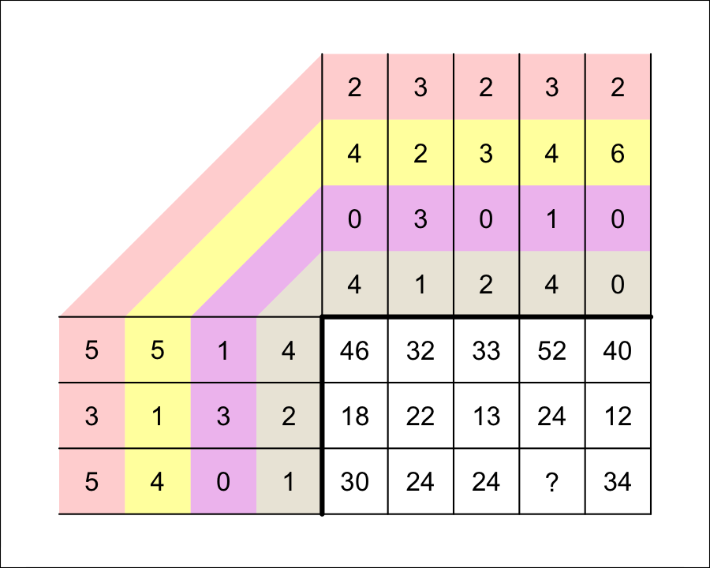

What is $c_{3,4}$?

To find $c_{3,4}$, you use row 3 from matrix $A$ and column 4 from matrix $B$.

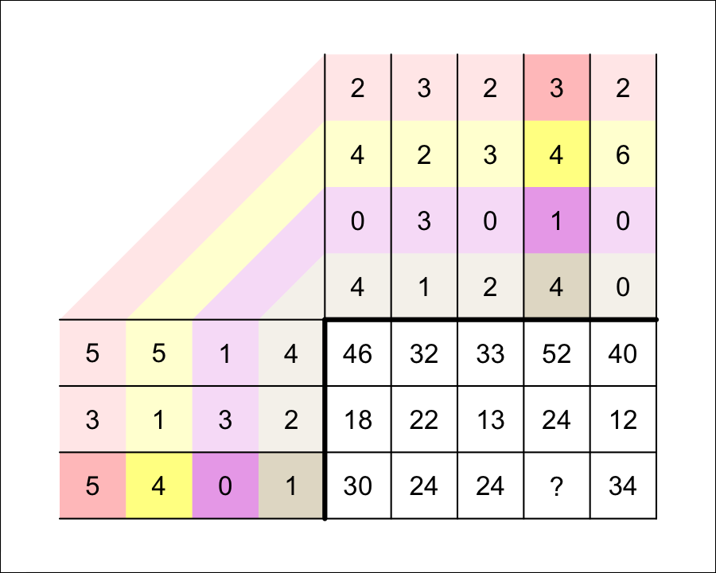

You multiply corresponding elements and sum those products.

$$c_{3,4}~=~( 5 \cdot 3 )+( 4 \cdot 4
)+( 0 \cdot 1 )+( 1 \cdot 4 )$$

$$c_{3,4}~=~15+16+0+4$$

$$c_{3,4}~=~35$$

Thus,

$$\begin{bmatrix}
5 & 5 & 1 & 4\\
3 & 1 & 3 & 2\\
5 & 4 & 0 & 1
\end{bmatrix} \cdot \begin{bmatrix}
2 & 3 & 2 & 3 & 2\\
4 & 2 & 3 & 4 & 6\\
0 & 3 & 0 & 1 & 0\\
4 & 1 & 2 & 4 & 0
\end{bmatrix} ~=~ \begin{bmatrix}
46 & 32 & 33 & 52 & 40\\
18 & 22 & 13 & 24 & 12\\
30 & 24 & 24 & 35 & 34
\end{bmatrix}$$

A matrix is a rectangular array of numbers. We typically represent matrices by placing numbers (the elements) in a regular rectangular formation inside large square brackets. For example, let matrix $A$ be defined below:

$$A~=~\begin{bmatrix}
32 & 93 & 33 & 59 & 21\\
64 & 67 & 68 & 95 & 49\\
87 & 35 & 23 & 56 & 36\\
41 & 77 & 61 & 46 & 91
\end{bmatrix}$$

Notice, matrix $A$ has 4 rows and 5 columns. We say $A$ is a 4-by-5 matrix. The matrix is composed of 20 elements. Each element has an "address": its row number and its column number (in that order!).

There are many notations for expressing the element at row $i$ and column $j$. Some options include $a_{ij}$ or $a_{i,\,j}$ or $A[i,j]$.

What element is in row 1 and column 2?

$$a_{1,2}~=~ ?$$

The element 93 is in row 1 and column 2.

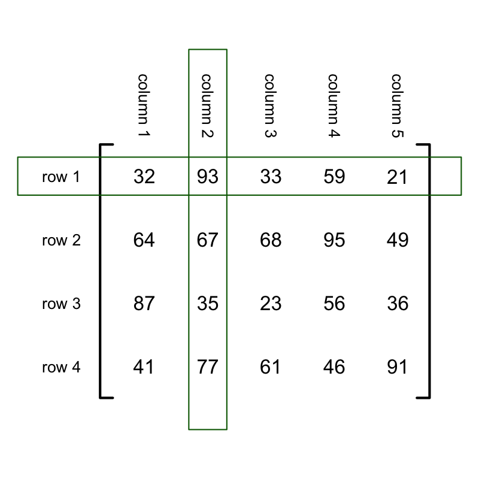

A matrix is a rectangular array of numbers. We typically represent matrices by placing numbers (the elements) in a regular rectangular formation inside large square brackets. For example, let matrix $A$ be defined below:

$$A~=~\begin{bmatrix}
14 & 38 & 94 & 20 & 25\\
50 & 67 & 69 & 82 & 19\\
83 & 18 & 90 & 57 & 58\\
16 & 85 & 66 & 27 & 75
\end{bmatrix}$$

Notice, matrix $A$ has 4 rows and 5 columns. We say $A$ is a 4-by-5 matrix. The matrix is composed of 20 elements. Each element has an "address": its row number and its column number (in that order!).

There are many notations for expressing the element at row $i$ and column $j$. Some options include $a_{ij}$ or $a_{i,\,j}$ or $A[i,j]$.

What element is in row 1 and column 3?

$$a_{1,3}~=~ ?$$

The element 94 is in row 1 and column 3.

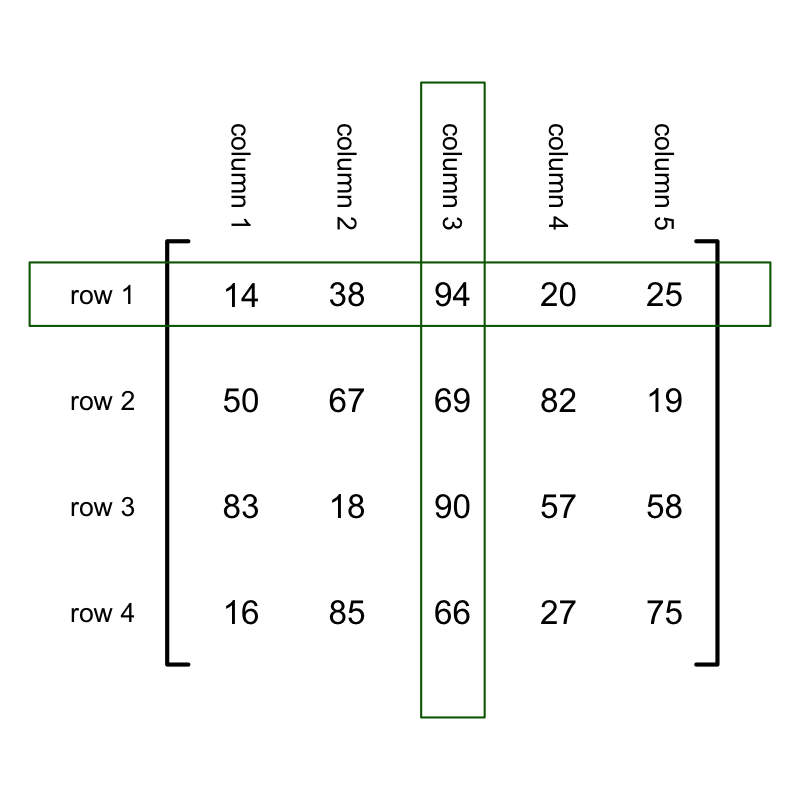

A matrix is a rectangular array of numbers. We typically represent matrices by placing numbers (the elements) in a regular rectangular formation inside large square brackets. For example, let matrix $A$ be defined below:

$$A~=~\begin{bmatrix}
59 & 17 & 16 & 25 & 50\\
71 & 66 & 52 & 79 & 82\\
13 & 43 & 53 & 46 & 12\\
23 & 65 & 90 & 91 & 32
\end{bmatrix}$$

Notice, matrix $A$ has 4 rows and 5 columns. We say $A$ is a 4-by-5 matrix. The matrix is composed of 20 elements. Each element has an "address": its row number and its column number (in that order!).

There are many notations for expressing the element at row $i$ and column $j$. Some options include $a_{ij}$ or $a_{i,\,j}$ or $A[i,j]$.

What element is in row 1 and column 2?

$$a_{1,2}~=~ ?$$

The element 17 is in row 1 and column 2.

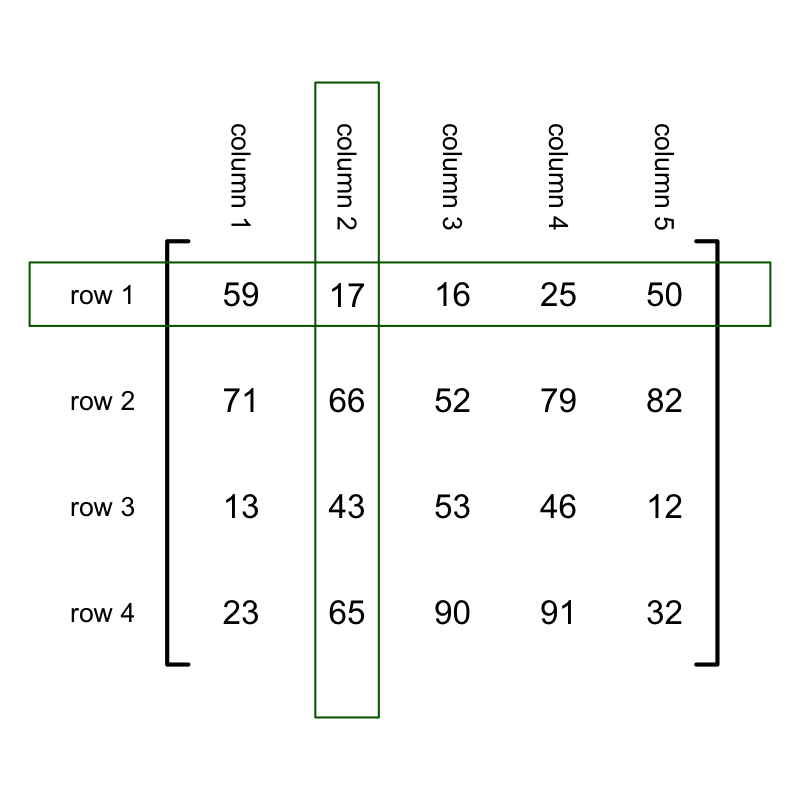

A matrix is a rectangular array of numbers. We typically represent matrices by placing numbers (the elements) in a regular rectangular formation inside large square brackets. For example, let matrix $A$ be defined below:

$$A~=~\begin{bmatrix}
65 & 51 & 82 & 52 & 37\\
38 & 33 & 96 & 25 & 88\\
36 & 55 & 98 & 12 & 66\\
14 & 17 & 42 & 49 & 64
\end{bmatrix}$$

Notice, matrix $A$ has 4 rows and 5 columns. We say $A$ is a 4-by-5 matrix. The matrix is composed of 20 elements. Each element has an "address": its row number and its column number (in that order!).

There are many notations for expressing the element at row $i$ and column $j$. Some options include $a_{ij}$ or $a_{i,\,j}$ or $A[i,j]$.

What element is in row 2 and column 3?

$$a_{2,3}~=~ ?$$

The element 96 is in row 2 and column 3.

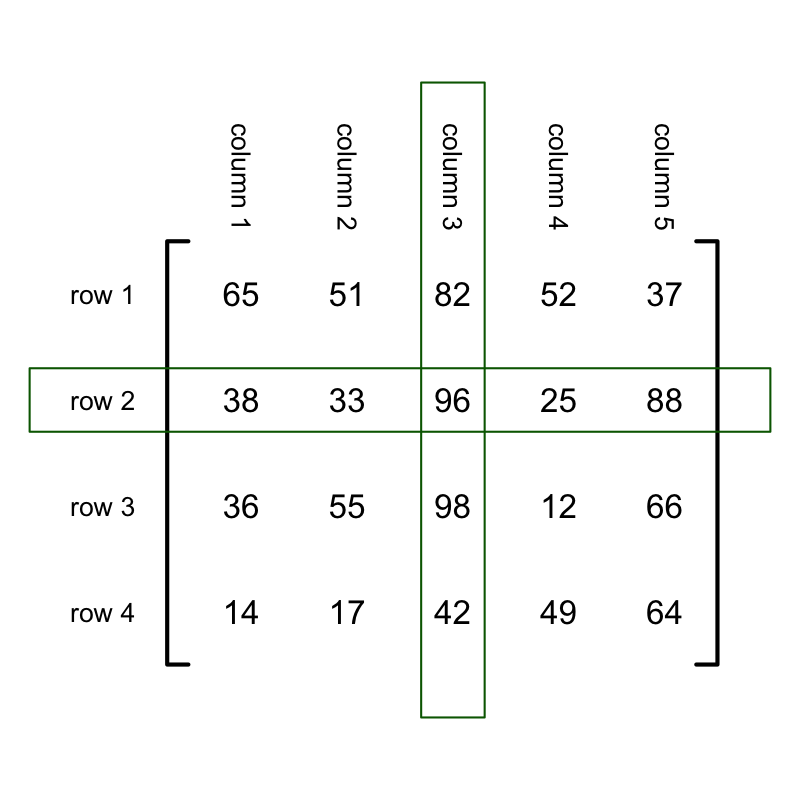

A matrix is a rectangular array of numbers. We typically represent matrices by placing numbers (the elements) in a regular rectangular formation inside large square brackets. For example, let matrix $A$ be defined below:

$$A~=~\begin{bmatrix}
25 & 12 & 65 & 92 & 34\\
82 & 59 & 15 & 23 & 97\\
75 & 27 & 22 & 77 & 93\\
19 & 76 & 63 & 91 & 88
\end{bmatrix}$$

Notice, matrix $A$ has 4 rows and 5 columns. We say $A$ is a 4-by-5 matrix. The matrix is composed of 20 elements. Each element has an "address": its row number and its column number (in that order!).

There are many notations for expressing the element at row $i$ and column $j$. Some options include $a_{ij}$ or $a_{i,\,j}$ or $A[i,j]$.

What element is in row 2 and column 4?

$$a_{2,4}~=~ ?$$

The element 23 is in row 2 and column 4.

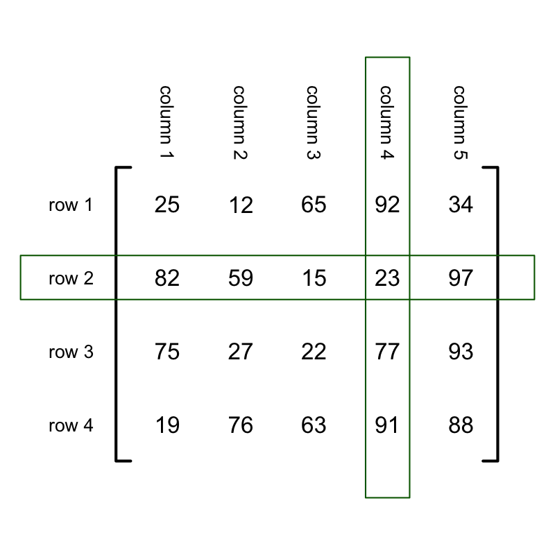

A matrix is a rectangular array of numbers. We typically represent matrices by placing numbers (the elements) in a regular rectangular formation inside large square brackets. For example, let matrix $A$ be defined below:

$$A~=~\begin{bmatrix}
99 & 92 & 93 & 60 & 96\\
87 & 33 & 91 & 80 & 30\\
89 & 58 & 75 & 62 & 17\\
37 & 82 & 43 & 49 & 28
\end{bmatrix}$$

Notice, matrix $A$ has 4 rows and 5 columns. We say $A$ is a 4-by-5 matrix. The matrix is composed of 20 elements. Each element has an "address": its row number and its column number (in that order!).

There are many notations for expressing the element at row $i$ and column $j$. Some options include $a_{ij}$ or $a_{i,\,j}$ or $A[i,j]$.

What element is in row 1 and column 4?

$$a_{1,4}~=~ ?$$

The element 60 is in row 1 and column 4.

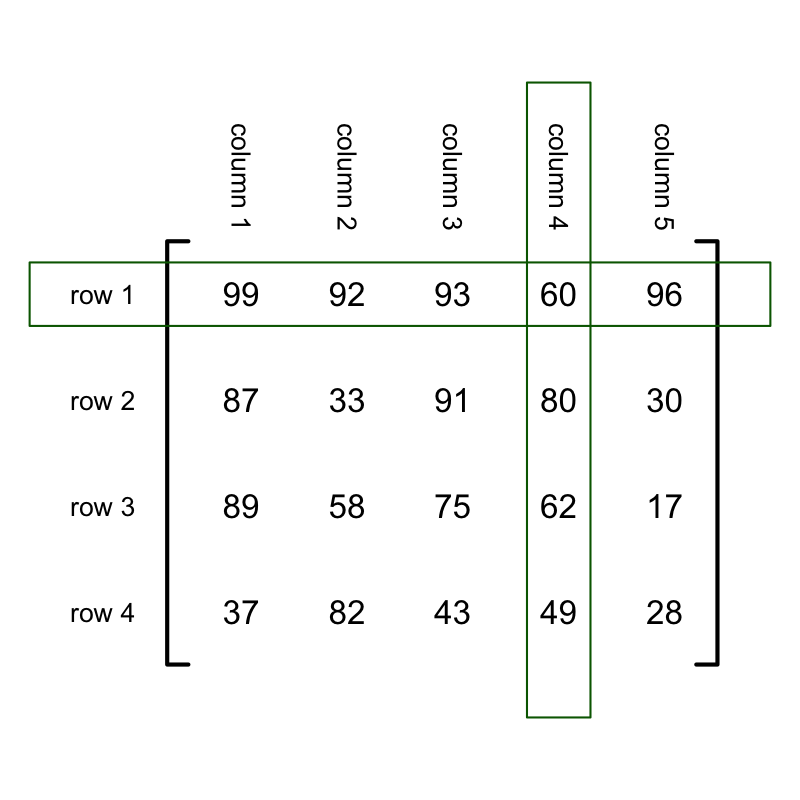

A matrix is a rectangular array of numbers. We typically represent matrices by placing numbers (the elements) in a regular rectangular formation inside large square brackets. For example, let matrix $A$ be defined below:

$$A~=~\begin{bmatrix}
19 & 27 & 77 & 87 & 80\\
76 & 71 & 82 & 85 & 89\\
47 & 38 & 51 & 13 & 73\\
72 & 33 & 32 & 97 & 40
\end{bmatrix}$$

Notice, matrix $A$ has 4 rows and 5 columns. We say $A$ is a 4-by-5 matrix. The matrix is composed of 20 elements. Each element has an "address": its row number and its column number (in that order!).

There are many notations for expressing the element at row $i$ and column $j$. Some options include $a_{ij}$ or $a_{i,\,j}$ or $A[i,j]$.

What element is in row 3 and column 2?

$$a_{3,2}~=~ ?$$

The element 38 is in row 3 and column 2.

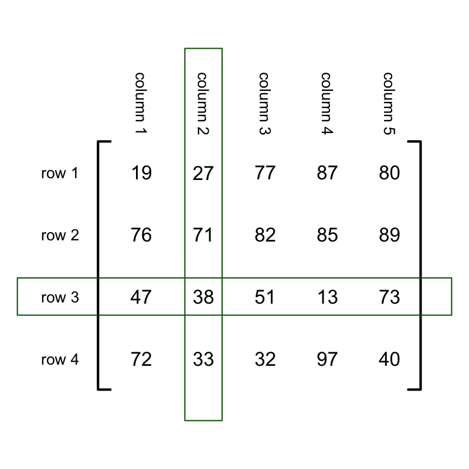

A matrix is a rectangular array of numbers. We typically represent matrices by placing numbers (the elements) in a regular rectangular formation inside large square brackets. For example, let matrix $A$ be defined below:

$$A~=~\begin{bmatrix}
73 & 18 & 65 & 23 & 93\\
77 & 39 & 38 & 58 & 35\\
71 & 13 & 54 & 63 & 89\\
43 & 95 & 37 & 88 & 81
\end{bmatrix}$$

Notice, matrix $A$ has 4 rows and 5 columns. We say $A$ is a 4-by-5 matrix. The matrix is composed of 20 elements. Each element has an "address": its row number and its column number (in that order!).

There are many notations for expressing the element at row $i$ and column $j$. Some options include $a_{ij}$ or $a_{i,\,j}$ or $A[i,j]$.

What element is in row 3 and column 4?

$$a_{3,4}~=~ ?$$

The element 63 is in row 3 and column 4.

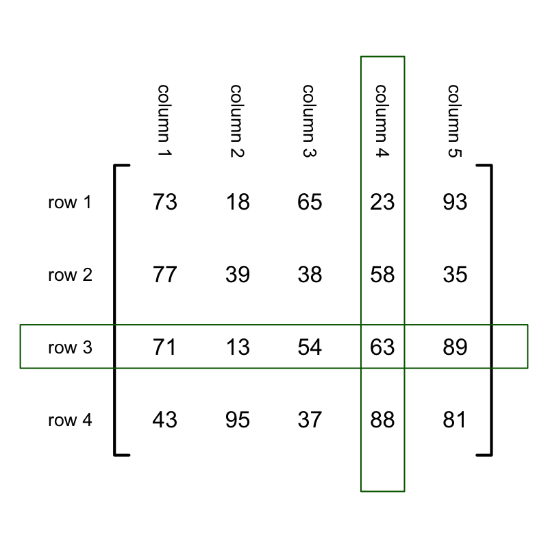

A matrix is a rectangular array of numbers. We typically represent matrices by placing numbers (the elements) in a regular rectangular formation inside large square brackets. For example, let matrix $A$ be defined below:

$$A~=~\begin{bmatrix}
90 & 60 & 75 & 27 & 81\\
97 & 56 & 35 & 96 & 70\\
17 & 95 & 87 & 48 & 11\\
74 & 40 & 85 & 45 & 99
\end{bmatrix}$$

Notice, matrix $A$ has 4 rows and 5 columns. We say $A$ is a 4-by-5 matrix. The matrix is composed of 20 elements. Each element has an "address": its row number and its column number (in that order!).

There are many notations for expressing the element at row $i$ and column $j$. Some options include $a_{ij}$ or $a_{i,\,j}$ or $A[i,j]$.

What element is in row 4 and column 3?

$$a_{4,3}~=~ ?$$

The element 85 is in row 4 and column 3.

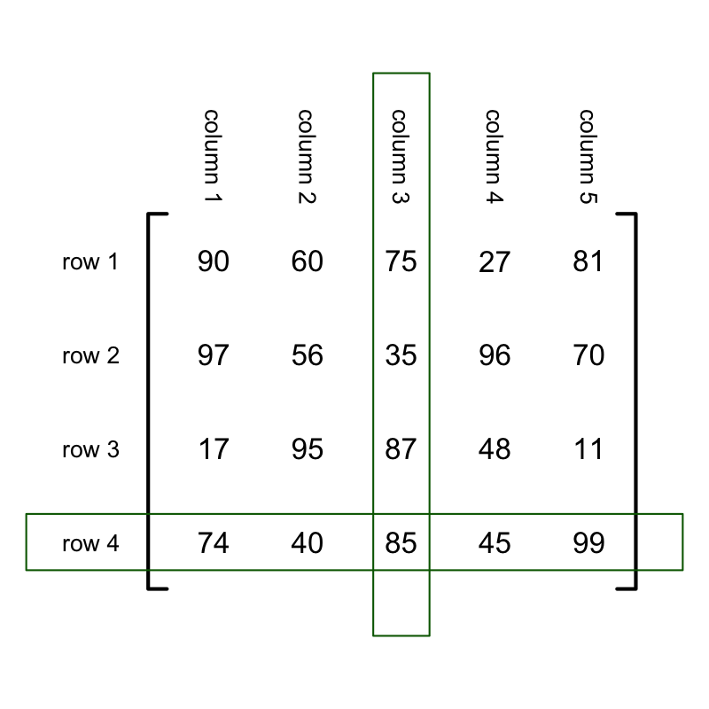

A matrix is a rectangular array of numbers. We typically represent matrices by placing numbers (the elements) in a regular rectangular formation inside large square brackets. For example, let matrix $A$ be defined below:

$$A~=~\begin{bmatrix}
71 & 49 & 29 & 61 & 93\\
91 & 99 & 12 & 65 & 33\\
11 & 15 & 74 & 23 & 45\\
36 & 83 & 60 & 39 & 22
\end{bmatrix}$$

Notice, matrix $A$ has 4 rows and 5 columns. We say $A$ is a 4-by-5 matrix. The matrix is composed of 20 elements. Each element has an "address": its row number and its column number (in that order!).

There are many notations for expressing the element at row $i$ and column $j$. Some options include $a_{ij}$ or $a_{i,\,j}$ or $A[i,j]$.

What element is in row 3 and column 4?

$$a_{3,4}~=~ ?$$

The element 23 is in row 3 and column 4.

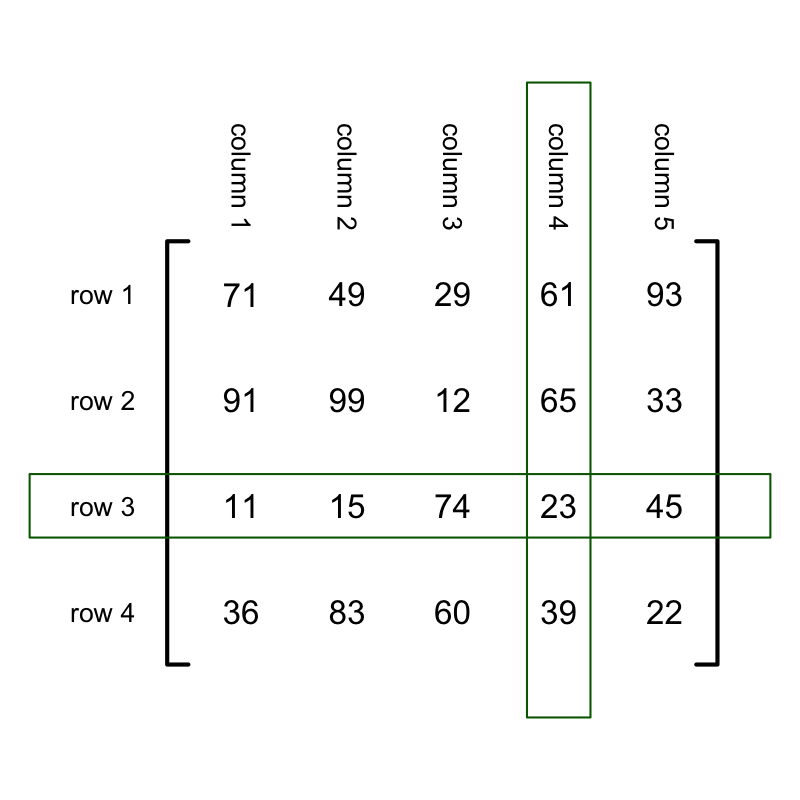

A matrix is a rectangular array of numbers. We typically represent matrices by placing numbers (the elements) in a regular rectangular formation inside large square brackets. For example, let matrix $A$ be defined below:

$$A~=~\begin{bmatrix}
15 & 96 & 39 & 86 & 24\\
49 & 94 & 34 & 20 & 54\\
95 & 98 & 66 & 85 & 57\\
83 & 91 & 58 & 17 & 48
\end{bmatrix}$$

Notice, matrix $A$ has 4 rows and 5 columns. We say $A$ is a 4-by-5 matrix. The matrix is composed of 20 elements. Each element has an "address": its row number and its column number (in that order!).

There are many notations for expressing the element at row $i$ and column $j$. Some options include $a_{ij}$ or $a_{i,\,j}$ or $A[i,j]$.

What element is in row 2 and column 3?

$$a_{2,3}~=~ ?$$

The element 34 is in row 2 and column 3.

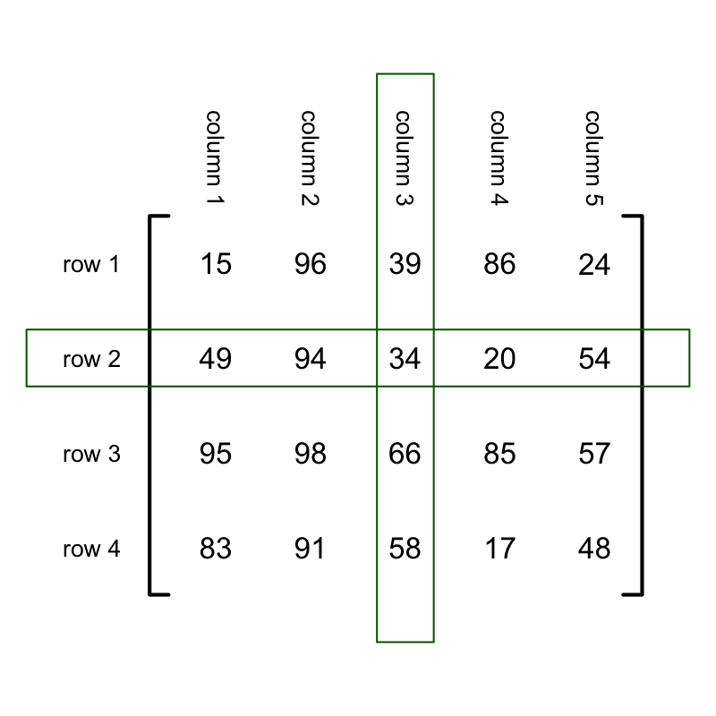

A matrix is a rectangular array of numbers. We typically represent matrices by placing numbers (the elements) in a regular rectangular formation inside large square brackets. For example, let matrix $A$ be defined below:

$$A~=~\begin{bmatrix}
16 & 76 & 77 & 40 & 18\\
11 & 38 & 74 & 26 & 33\\
13 & 19 & 29 & 22 & 44\\
17 & 90 & 72 & 97 & 71
\end{bmatrix}$$

Notice, matrix $A$ has 4 rows and 5 columns. We say $A$ is a 4-by-5 matrix. The matrix is composed of 20 elements. Each element has an "address": its row number and its column number (in that order!).

There are many notations for expressing the element at row $i$ and column $j$. Some options include $a_{ij}$ or $a_{i,\,j}$ or $A[i,j]$.

What element is in row 2 and column 3?

$$a_{2,3}~=~ ?$$

The element 74 is in row 2 and column 3.

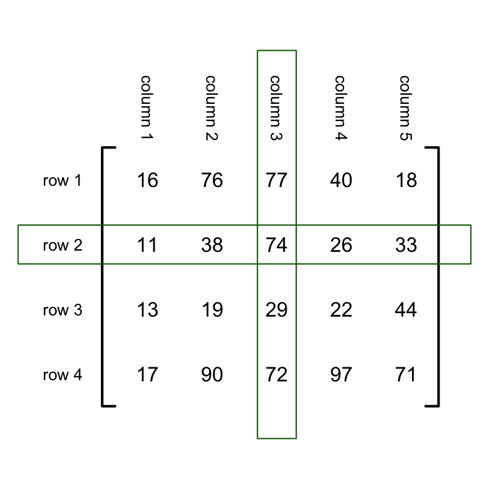

A matrix is a rectangular array of numbers. We typically represent matrices by placing numbers (the elements) in a regular rectangular formation inside large square brackets. For example, let matrix $A$ be defined below:

$$A~=~\begin{bmatrix}
35 & 79 & 92 & 34 & 23\\
36 & 12 & 97 & 48 & 29\\
13 & 18 & 65 & 47 & 56\\
53 & 17 & 93 & 44 & 98
\end{bmatrix}$$

Notice, matrix $A$ has 4 rows and 5 columns. We say $A$ is a 4-by-5 matrix. The matrix is composed of 20 elements. Each element has an "address": its row number and its column number (in that order!).

There are many notations for expressing the element at row $i$ and column $j$. Some options include $a_{ij}$ or $a_{i,\,j}$ or $A[i,j]$.

What element is in row 3 and column 1?

$$a_{3,1}~=~ ?$$

The element 13 is in row 3 and column 1.

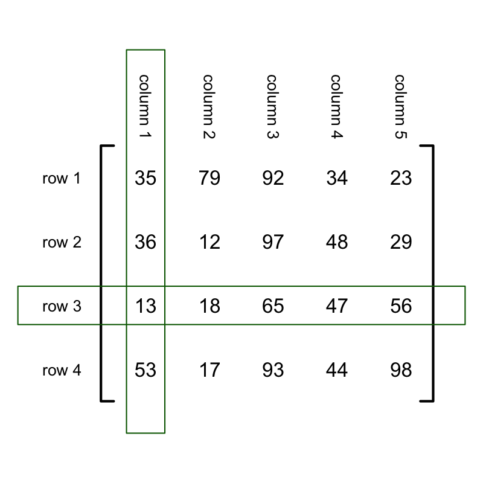

A matrix is a rectangular array of numbers. We typically represent matrices by placing numbers (the elements) in a regular rectangular formation inside large square brackets. For example, let matrix $A$ be defined below:

$$A~=~\begin{bmatrix}
31 & 42 & 36 & 29 & 95\\
15 & 76 & 45 & 60 & 39\\
11 & 13 & 77 & 38 & 22\\
25 & 72 & 26 & 96 & 87
\end{bmatrix}$$

Notice, matrix $A$ has 4 rows and 5 columns. We say $A$ is a 4-by-5 matrix. The matrix is composed of 20 elements. Each element has an "address": its row number and its column number (in that order!).

There are many notations for expressing the element at row $i$ and column $j$. Some options include $a_{ij}$ or $a_{i,\,j}$ or $A[i,j]$.

What element is in row 4 and column 2?

$$a_{4,2}~=~ ?$$

The element 72 is in row 4 and column 2.

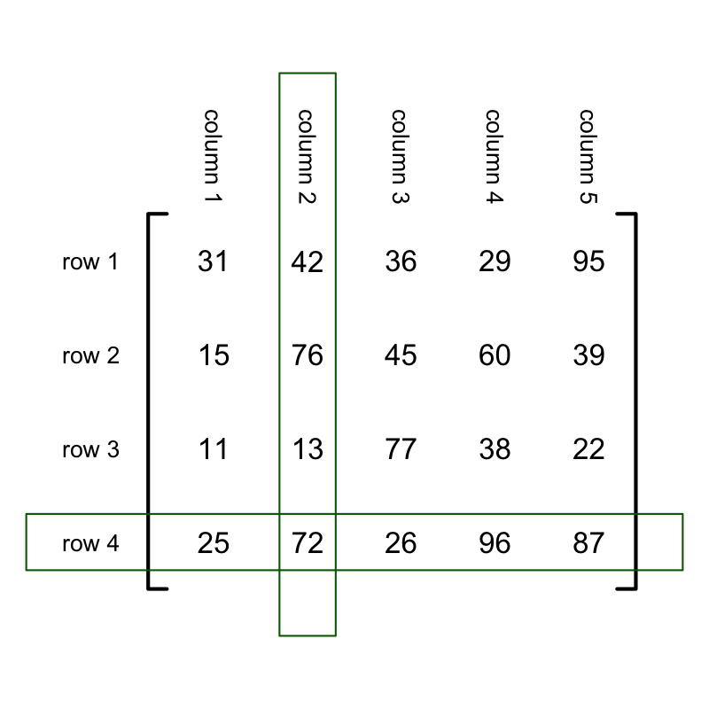

A matrix is a rectangular array of numbers. We typically represent matrices by placing numbers (the elements) in a regular rectangular formation inside large square brackets. For example, let matrix $A$ be defined below:

$$A~=~\begin{bmatrix}
27 & 87 & 36 & 83 & 21\\
38 & 35 & 47 & 60 & 75\\
57 & 41 & 86 & 76 & 88\\
67 & 97 & 63 & 34 & 65
\end{bmatrix}$$

Notice, matrix $A$ has 4 rows and 5 columns. We say $A$ is a 4-by-5 matrix. The matrix is composed of 20 elements. Each element has an "address": its row number and its column number (in that order!).

There are many notations for expressing the element at row $i$ and column $j$. Some options include $a_{ij}$ or $a_{i,\,j}$ or $A[i,j]$.

What element is in row 2 and column 4?

$$a_{2,4}~=~ ?$$

The element 60 is in row 2 and column 4.

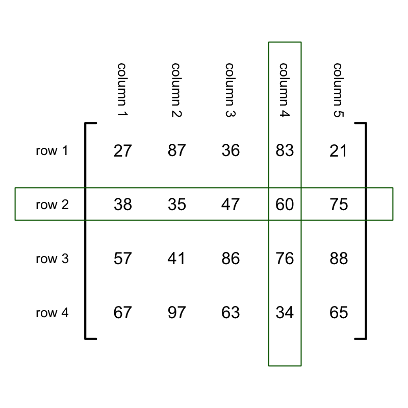

A matrix is a rectangular array of numbers. We typically represent matrices by placing numbers (the elements) in a regular rectangular formation inside large square brackets. For example, let matrix $A$ be defined below:

$$A~=~\begin{bmatrix}
65 & 98 & 38 & 92 & 36\\
91 & 97 & 19 & 33 & 21\\
23 & 13 & 68 & 60 & 75\\
27 & 83 & 95 & 67 & 66
\end{bmatrix}$$

Notice, matrix $A$ has 4 rows and 5 columns. We say $A$ is a 4-by-5 matrix. The matrix is composed of 20 elements. Each element has an "address": its row number and its column number (in that order!).

There are many notations for expressing the element at row $i$ and column $j$. Some options include $a_{ij}$ or $a_{i,\,j}$ or $A[i,j]$.

What element is in row 1 and column 3?

$$a_{1,3}~=~ ?$$

The element 38 is in row 1 and column 3.

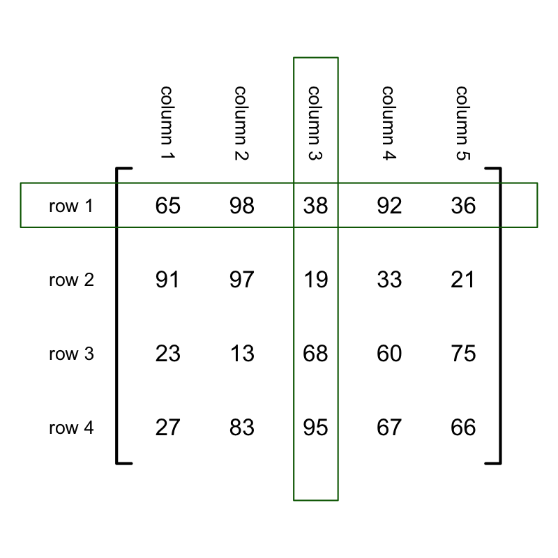

A matrix is a rectangular array of numbers. We typically represent matrices by placing numbers (the elements) in a regular rectangular formation inside large square brackets. For example, let matrix $A$ be defined below:

$$A~=~\begin{bmatrix}
37 & 57 & 61 & 84 & 53\\
96 & 35 & 41 & 25 & 33\\
42 & 28 & 27 & 14 & 83\\
54 & 97 & 59 & 85 & 88
\end{bmatrix}$$

Notice, matrix $A$ has 4 rows and 5 columns. We say $A$ is a 4-by-5 matrix. The matrix is composed of 20 elements. Each element has an "address": its row number and its column number (in that order!).

There are many notations for expressing the element at row $i$ and column $j$. Some options include $a_{ij}$ or $a_{i,\,j}$ or $A[i,j]$.

What element is in row 4 and column 2?

$$a_{4,2}~=~ ?$$

The element 97 is in row 4 and column 2.

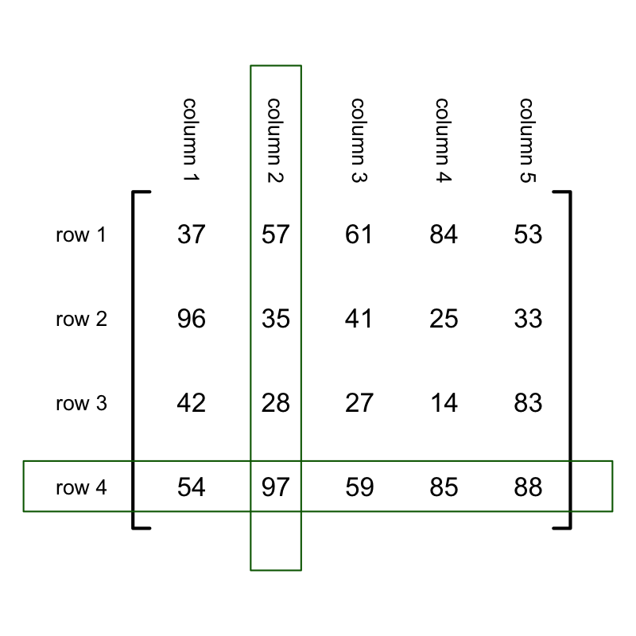

A matrix is a rectangular array of numbers. We typically represent matrices by placing numbers (the elements) in a regular rectangular formation inside large square brackets. For example, let matrix $A$ be defined below:

$$A~=~\begin{bmatrix}
84 & 19 & 99 & 51 & 12\\
80 & 32 & 47 & 33 & 41\\
14 & 95 & 70 & 23 & 88\\
46 & 79 & 26 & 44 & 11
\end{bmatrix}$$

Notice, matrix $A$ has 4 rows and 5 columns. We say $A$ is a 4-by-5 matrix. The matrix is composed of 20 elements. Each element has an "address": its row number and its column number (in that order!).

There are many notations for expressing the element at row $i$ and column $j$. Some options include $a_{ij}$ or $a_{i,\,j}$ or $A[i,j]$.

What element is in row 3 and column 2?

$$a_{3,2}~=~ ?$$

The element 95 is in row 3 and column 2.

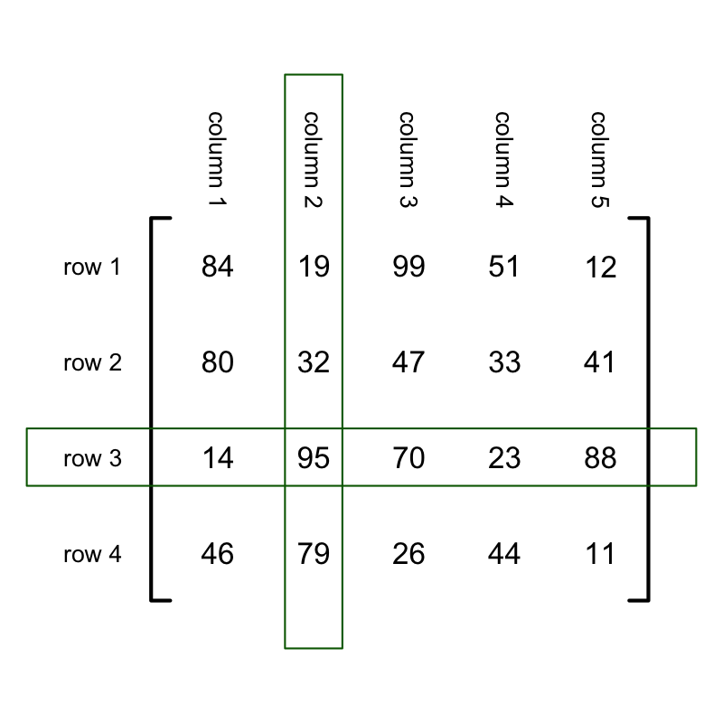

A matrix is a rectangular array of numbers. We typically represent matrices by placing numbers (the elements) in a regular rectangular formation inside large square brackets. For example, let matrix $A$ be defined below:

$$A~=~\begin{bmatrix}
55 & 90 & 23 & 85 & 37\\
84 & 76 & 89 & 60 & 87\\
54 & 51 & 52 & 58 & 62\\
77 & 19 & 99 & 48 & 75
\end{bmatrix}$$

Notice, matrix $A$ has 4 rows and 5 columns. We say $A$ is a 4-by-5 matrix. The matrix is composed of 20 elements. Each element has an "address": its row number and its column number (in that order!).

There are many notations for expressing the element at row $i$ and column $j$. Some options include $a_{ij}$ or $a_{i,\,j}$ or $A[i,j]$.

What element is in row 3 and column 1?

$$a_{3,1}~=~ ?$$

The element 54 is in row 3 and column 1.

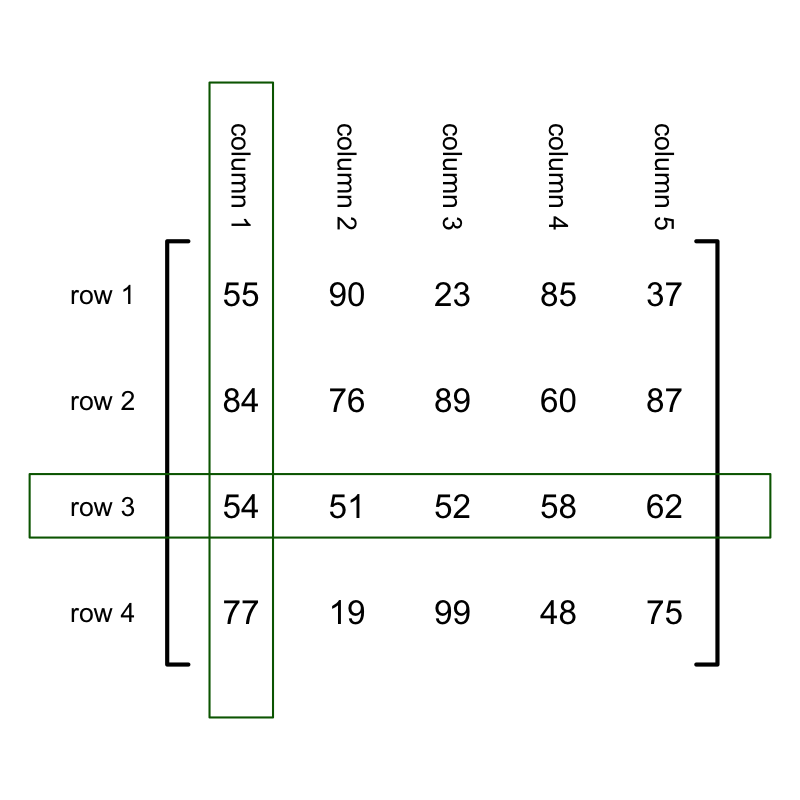

A matrix is a rectangular array of numbers. We typically represent matrices by placing numbers (the elements) in a regular rectangular formation inside large square brackets. For example, let matrix $A$ be defined below:

$$A~=~\begin{bmatrix}
50 & 51 & 77 & 57 & 82\\
64 & 53 & 20 & 35 & 94\\
73 & 84 & 18 & 85 & 30\\
38 & 29 & 89 & 58 & 99
\end{bmatrix}$$

Notice, matrix $A$ has 4 rows and 5 columns. We say $A$ is a 4-by-5 matrix. The matrix is composed of 20 elements. Each element has an "address": its row number and its column number (in that order!).

There are many notations for expressing the element at row $i$ and column $j$. Some options include $a_{ij}$ or $a_{i,\,j}$ or $A[i,j]$.

What element is in row 3 and column 1?

$$a_{3,1}~=~ ?$$

The element 73 is in row 3 and column 1.

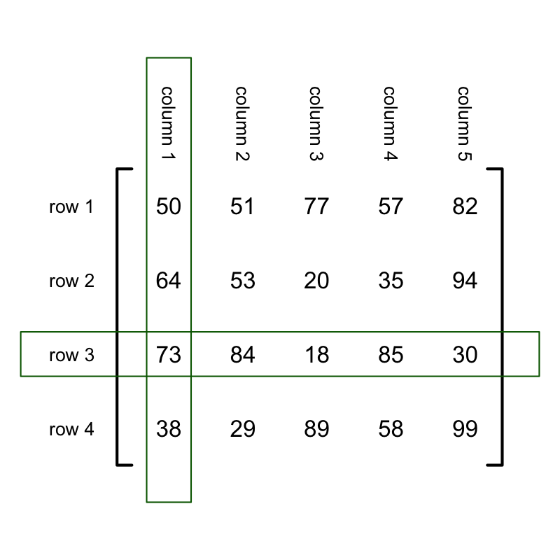

Let matrix $A$ be defined below:

$$A~=~\begin{bmatrix}
35 & 14 & 51 & 65 & 88\\
28 & 40 & 87 & 16 & 45\\
73 & 91 & 47 & 32 & 81\\
99 & 77 & 55 & 24 & 25
\end{bmatrix}$$

Find the element indicated below.

$$a_{3,1}~=~ ?$$

The element 73 is in row 3 and column 1.

Let matrix $A$ be defined below:

$$A~=~\begin{bmatrix}
13 & 72 & 60 & 46 & 97\\
25 & 71 & 83 & 28 & 74\\
73 & 63 & 80 & 48 & 62\\
81 & 94 & 30 & 68 & 86
\end{bmatrix}$$

Find the element indicated below.

$$a_{1,2}~=~ ?$$

The element 72 is in row 1 and column 2.

Let matrix $A$ be defined below:

$$A~=~\begin{bmatrix}
12 & 41 & 31 & 20 & 48\\
30 & 19 & 33 & 57 & 78\\
58 & 56 & 67 & 47 & 82\\
46 & 28 & 43 & 99 & 77
\end{bmatrix}$$

Find the element indicated below.

$$a_{1,2}~=~ ?$$

The element 41 is in row 1 and column 2.

Let matrix $A$ be defined below:

$$A~=~\begin{bmatrix}
56 & 38 & 11 & 25 & 47\\
75 & 14 & 30 & 31 & 43\\
78 & 46 & 89 & 26 & 19\\
95 & 93 & 81 & 45 & 59
\end{bmatrix}$$

Find the element indicated below.

$$a_{2,3}~=~ ?$$

The element 30 is in row 2 and column 3.

Let matrix $A$ be defined below:

$$A~=~\begin{bmatrix}
12 & 59 & 18 & 29 & 64\\
81 & 30 & 67 & 84 & 48\\
23 & 17 & 41 & 63 & 85\\
69 & 70 & 65 & 28 & 91
\end{bmatrix}$$

Find the element indicated below.

$$a_{2,3}~=~ ?$$

The element 67 is in row 2 and column 3.

Let matrix $A$ be defined below:

$$A~=~\begin{bmatrix}
13 & 87 & 50 & 83 & 18\\
16 & 41 & 96 & 45 & 88\\
12 & 51 & 82 & 26 & 91\\
48 & 42 & 19 & 36 & 85
\end{bmatrix}$$

Find the element indicated below.

$$a_{3,1}~=~ ?$$

The element 12 is in row 3 and column 1.

Let matrix $A$ be defined below:

$$A~=~\begin{bmatrix}
28 & 51 & 54 & 74 & 33\\
68 & 94 & 23 & 15 & 59\\
57 & 76 & 45 & 92 & 63\\
42 & 83 & 62 & 37 & 64
\end{bmatrix}$$

Find the element indicated below.

$$a_{1,2}~=~ ?$$

The element 51 is in row 1 and column 2.

Let matrix $A$ be defined below:

$$A~=~\begin{bmatrix}
59 & 69 & 31 & 38 & 27\\
57 & 70 & 36 & 30 & 18\\
52 & 98 & 97 & 13 & 91\\
32 & 34 & 50 & 71 & 40
\end{bmatrix}$$

Find the element indicated below.

$$a_{2,4}~=~ ?$$

The element 30 is in row 2 and column 4.

Let matrix $A$ be defined below:

$$A~=~\begin{bmatrix}
89 & 79 & 84 & 93 & 30\\
23 & 53 & 37 & 19 & 68\\
60 & 49 & 14 & 97 & 80\\
20 & 88 & 74 & 76 & 92
\end{bmatrix}$$

Find the element indicated below.

$$a_{3,2}~=~ ?$$

The element 49 is in row 3 and column 2.

Let matrix $A$ be defined below:

$$A~=~\begin{bmatrix}
66 & 33 & 92 & 83 & 43\\
13 & 51 & 94 & 53 & 76\\
38 & 42 & 44 & 48 & 60\\
75 & 31 & 85 & 35 & 21
\end{bmatrix}$$

Find the element indicated below.

$$a_{4,2}~=~ ?$$

The element 31 is in row 4 and column 2.

Let matrix $A$ be defined below:

$$A~=~\begin{bmatrix}
49 & 82 & 76 & 19 & 44\\
81 & 16 & 17 & 79 & 58\\
22 & 40 & 18 & 75 & 39\\
72 & 74 & 48 & 87 & 70
\end{bmatrix}$$

Find the element indicated below.

$$a_{1,3}~=~ ?$$

The element 76 is in row 1 and column 3.

Let matrix $A$ be defined below:

$$A~=~\begin{bmatrix}
69 & 63 & 98 & 40 & 39\\
24 & 32 & 78 & 61 & 74\\
44 & 93 & 73 & 99 & 71\\
17 & 12 & 30 & 28 & 80
\end{bmatrix}$$

Find the element indicated below.

$$a_{4,2}~=~ ?$$

The element 12 is in row 4 and column 2.

Let matrix $A$ be defined below:

$$A~=~\begin{bmatrix}
65 & 80 & 17 & 49 & 95\\
14 & 83 & 24 & 25 & 55\\
36 & 88 & 92 & 74 & 60\\
39 & 23 & 64 & 53 & 40
\end{bmatrix}$$

Find the element indicated below.

$$a_{3,4}~=~ ?$$

The element 74 is in row 3 and column 4.

Let matrix $A$ be defined below:

$$A~=~\begin{bmatrix}
58 & 17 & 90 & 30 & 69\\
32 & 85 & 72 & 61 & 70\\
73 & 80 & 34 & 74 & 71\\
79 & 51 & 60 & 11 & 33
\end{bmatrix}$$

Find the element indicated below.

$$a_{4,1}~=~ ?$$

The element 79 is in row 4 and column 1.

Let matrix $A$ be defined below:

$$A~=~\begin{bmatrix}
66 & 59 & 12 & 86 & 60\\
19 & 79 & 58 & 68 & 13\\
42 & 81 & 69 & 51 & 71\\
21 & 22 & 26 & 18 & 32
\end{bmatrix}$$

Find the element indicated below.

$$a_{1,3}~=~ ?$$

The element 12 is in row 1 and column 3.

Let matrix $A$ be defined below:

$$A~=~\begin{bmatrix}
25 & 53 & 96 & 64 & 14\\
22 & 98 & 17 & 24 & 19\\
35 & 70 & 55 & 48 & 66\\
27 & 47 & 92 & 69 & 34
\end{bmatrix}$$

Find the element indicated below.

$$a_{2,1}~=~ ?$$

The element 22 is in row 2 and column 1.

Let matrix $A$ be defined below:

$$A~=~\begin{bmatrix}
34 & 72 & 93 & 62 & 69\\
63 & 48 & 39 & 33 & 17\\
47 & 66 & 12 & 38 & 57\\
64 & 85 & 83 & 32 & 26
\end{bmatrix}$$

Find the element indicated below.

$$a_{2,3}~=~ ?$$

The element 39 is in row 2 and column 3.

Let matrix $A$ be defined below:

$$A~=~\begin{bmatrix}
26 & 44 & 93 & 88 & 47\\
57 & 78 & 86 & 55 & 97\\
36 & 75 & 81 & 71 & 41\\
11 & 33 & 24 & 66 & 38
\end{bmatrix}$$

Find the element indicated below.

$$a_{3,1}~=~ ?$$

The element 36 is in row 3 and column 1.

Let matrix $A$ be defined below:

$$A~=~\begin{bmatrix}
55 & 54 & 27 & 38 & 12\\
37 & 33 & 34 & 70 & 67\\
26 & 11 & 25 & 41 & 39\\
92 & 58 & 85 & 52 & 95
\end{bmatrix}$$

Find the element indicated below.

$$a_{2,4}~=~ ?$$

The element 70 is in row 2 and column 4.

Let matrix $A$ be defined below:

$$A~=~\begin{bmatrix}
59 & 80 & 97 & 50 & 87\\
18 & 16 & 57 & 93 & 62\\
79 & 15 & 86 & 51 & 13\\
17 & 30 & 53 & 32 & 33
\end{bmatrix}$$

Find the element indicated below.

$$a_{2,4}~=~ ?$$

The element 93 is in row 2 and column 4.

Let matrices $A$ and $B$ be defined below.

$$A = \begin{bmatrix}
1 & 5 & 2\\
7 & 4 & 9\\
3 & 8 & 6
\end{bmatrix}$$
$$B = \begin{bmatrix}
4 & 5 & 9\\
8 & 6 & 2\\
3 & 1 & 7
\end{bmatrix}$$

A third matrix, $C$, is equal to the [product](https://en.wikipedia.org/wiki/Matrix_multiplication) $AB$. A student set up a diagram to help find the product:

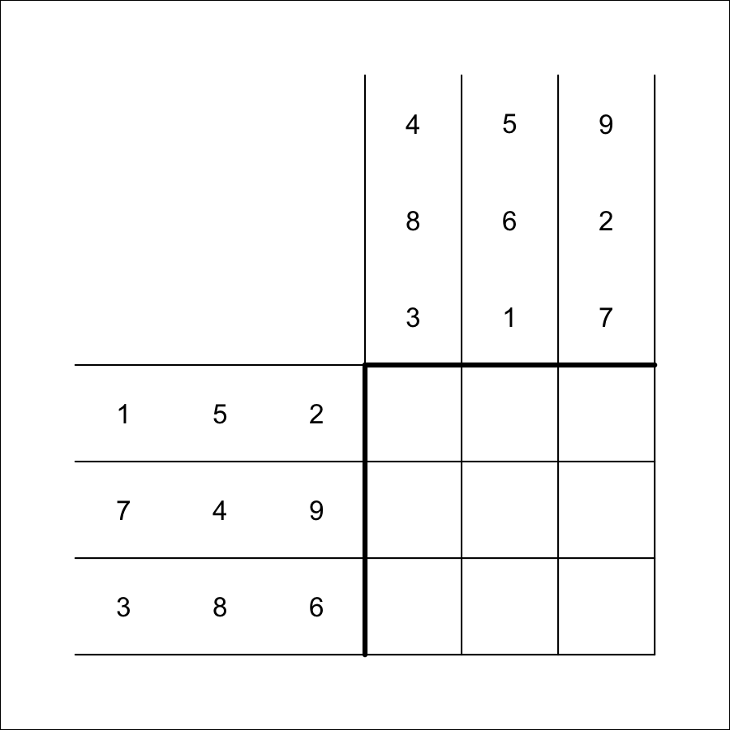

What is $c_{2,1}$?

To find $c_{2,1}$, you use row 2 from matrix $A$ and column 1 from matrix $B$.

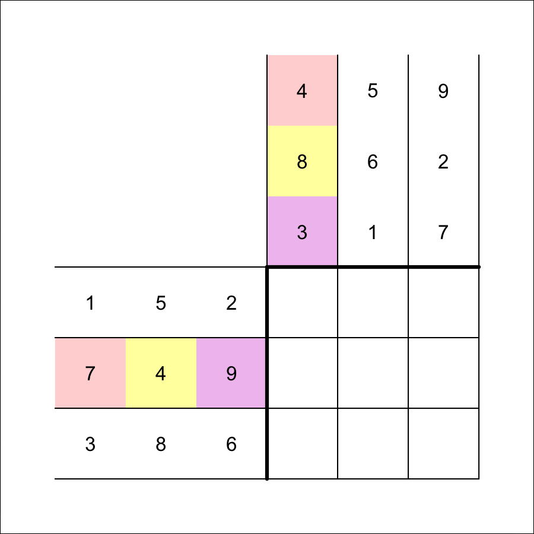

You multiply corresponding elements and sum those products.

$$c_{2,1}~=~( 7 \cdot 4 )+( 4 \cdot 8
)+( 9 \cdot 3 )$$

$$c_{2,1}~=~28+32+27$$

$$c_{2,1}~=~87$$

If you repeat this process for all 9 elements in $C$, you get:

$$\begin{bmatrix}
1 & 5 & 2\\
7 & 4 & 9\\
3 & 8 & 6
\end{bmatrix} \cdot \begin{bmatrix}
4 & 5 & 9\\
8 & 6 & 2\\
3 & 1 & 7
\end{bmatrix} ~=~ \begin{bmatrix}
50 & 37 & 33\\
87 & 68 & 134\\
94 & 69 & 85
\end{bmatrix}$$

Let matrices $A$ and $B$ be defined below.

$$A = \begin{bmatrix}
6 & 1 & 7\\
3 & 2 & 5\\
8 & 4 & 9
\end{bmatrix}$$
$$B = \begin{bmatrix}
6 & 5 & 2\\
3 & 8 & 4\\
1 & 9 & 7
\end{bmatrix}$$

A third matrix, $C$, is equal to the [product](https://en.wikipedia.org/wiki/Matrix_multiplication) $AB$. A student set up a diagram to help find the product:

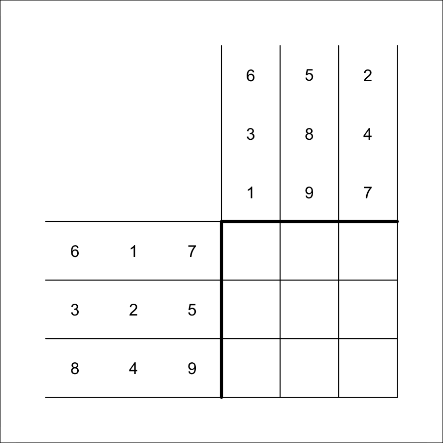

What is $c_{1,3}$?

To find $c_{1,3}$, you use row 1 from matrix $A$ and column 3 from matrix $B$.

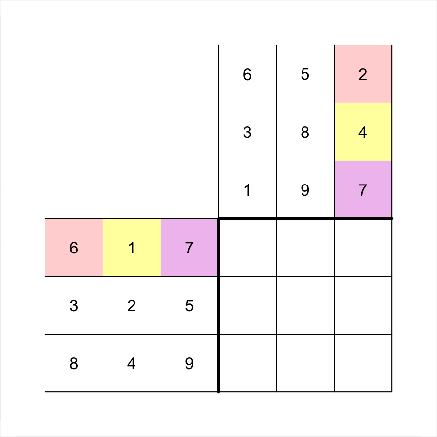

You multiply corresponding elements and sum those products.

$$c_{1,3}~=~( 6 \cdot 2 )+( 1 \cdot 4
)+( 7 \cdot 7 )$$

$$c_{1,3}~=~12+4+49$$

$$c_{1,3}~=~65$$

If you repeat this process for all 9 elements in $C$, you get:

$$\begin{bmatrix}
6 & 1 & 7\\
3 & 2 & 5\\
8 & 4 & 9
\end{bmatrix} \cdot \begin{bmatrix}
6 & 5 & 2\\
3 & 8 & 4\\
1 & 9 & 7
\end{bmatrix} ~=~ \begin{bmatrix}
46 & 101 & 65\\
29 & 76 & 49\\
69 & 153 & 95
\end{bmatrix}$$

Let matrices $A$ and $B$ be defined below.

$$A = \begin{bmatrix}
3 & 6 & 1\\
5 & 2 & 7\\
9 & 8 & 4
\end{bmatrix}$$
$$B = \begin{bmatrix}
3 & 8 & 7\\
6 & 4 & 5\\
1 & 2 & 9
\end{bmatrix}$$

A third matrix, $C$, is equal to the [product](https://en.wikipedia.org/wiki/Matrix_multiplication) $AB$. A student set up a diagram to help find the product:

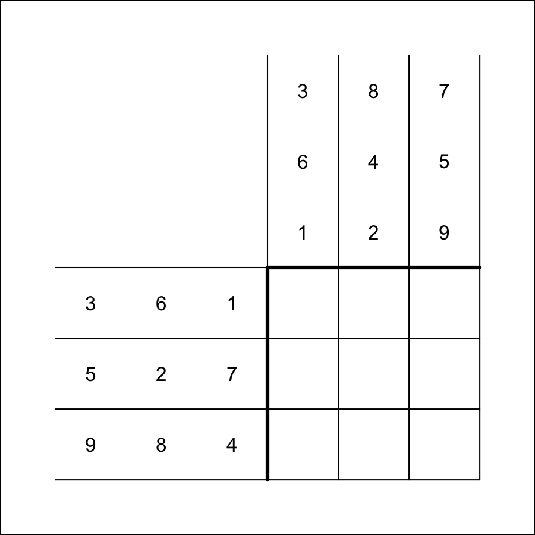

What is $c_{3,2}$?

To find $c_{3,2}$, you use row 3 from matrix $A$ and column 2 from matrix $B$.

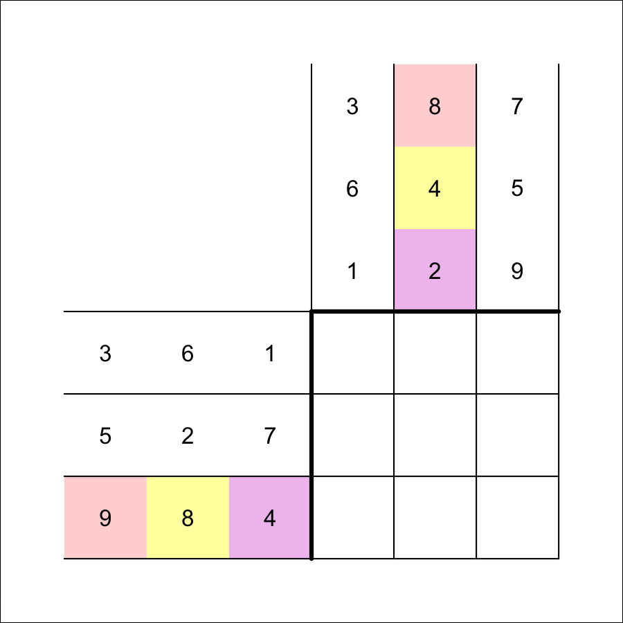

You multiply corresponding elements and sum those products.

$$c_{3,2}~=~( 9 \cdot 8 )+( 8 \cdot 4
)+( 4 \cdot 2 )$$

$$c_{3,2}~=~72+32+8$$

$$c_{3,2}~=~112$$

If you repeat this process for all 9 elements in $C$, you get:

$$\begin{bmatrix}
3 & 6 & 1\\
5 & 2 & 7\\
9 & 8 & 4
\end{bmatrix} \cdot \begin{bmatrix}
3 & 8 & 7\\
6 & 4 & 5\\
1 & 2 & 9
\end{bmatrix} ~=~ \begin{bmatrix}
46 & 50 & 60\\
34 & 62 & 108\\
79 & 112 & 139
\end{bmatrix}$$

Let matrices $A$ and $B$ be defined below.

$$A = \begin{bmatrix}
2 & 8 & 9\\
7 & 6 & 4\\
5 & 3 & 1
\end{bmatrix}$$
$$B = \begin{bmatrix}
5 & 8 & 6\\
1 & 3 & 9\\
2 & 4 & 7
\end{bmatrix}$$

A third matrix, $C$, is equal to the [product](https://en.wikipedia.org/wiki/Matrix_multiplication) $AB$. A student set up a diagram to help find the product:

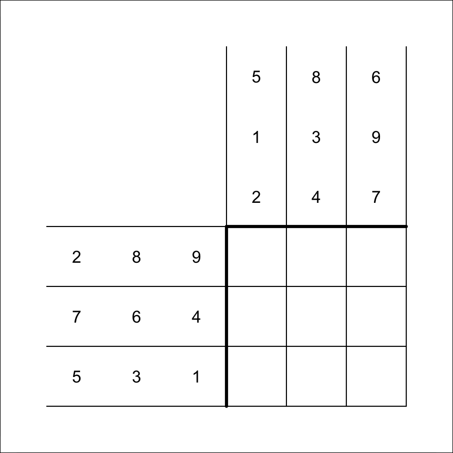

What is $c_{1,2}$?

To find $c_{1,2}$, you use row 1 from matrix $A$ and column 2 from matrix $B$.

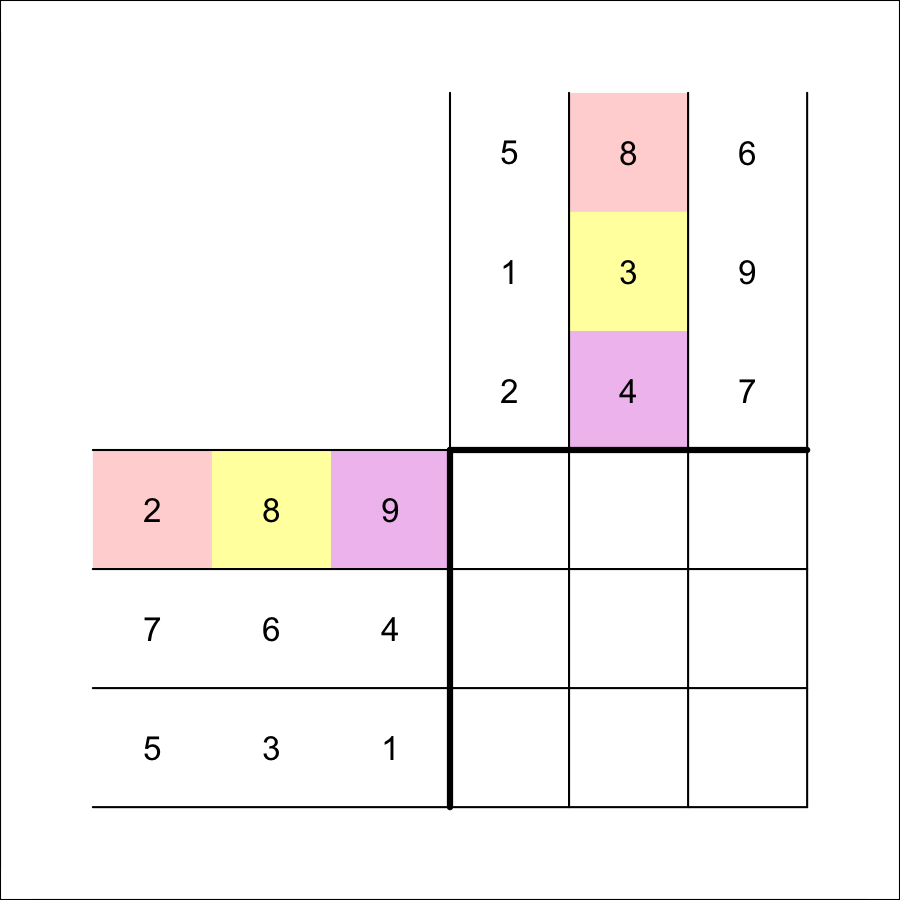

You multiply corresponding elements and sum those products.

$$c_{1,2}~=~( 2 \cdot 8 )+( 8 \cdot 3
)+( 9 \cdot 4 )$$

$$c_{1,2}~=~16+24+36$$

$$c_{1,2}~=~76$$

If you repeat this process for all 9 elements in $C$, you get:

$$\begin{bmatrix}
2 & 8 & 9\\
7 & 6 & 4\\
5 & 3 & 1
\end{bmatrix} \cdot \begin{bmatrix}
5 & 8 & 6\\
1 & 3 & 9\\
2 & 4 & 7
\end{bmatrix} ~=~ \begin{bmatrix}
36 & 76 & 147\\
49 & 90 & 124\\
30 & 53 & 64
\end{bmatrix}$$

Let matrices $A$ and $B$ be defined below.

$$A = \begin{bmatrix}
3 & 1 & 5\\
8 & 2 & 7\\
9 & 4 & 6
\end{bmatrix}$$
$$B = \begin{bmatrix}
8 & 6 & 9\\
4 & 3 & 1\\
7 & 2 & 5
\end{bmatrix}$$

A third matrix, $C$, is equal to the [product](https://en.wikipedia.org/wiki/Matrix_multiplication) $AB$. A student set up a diagram to help find the product:

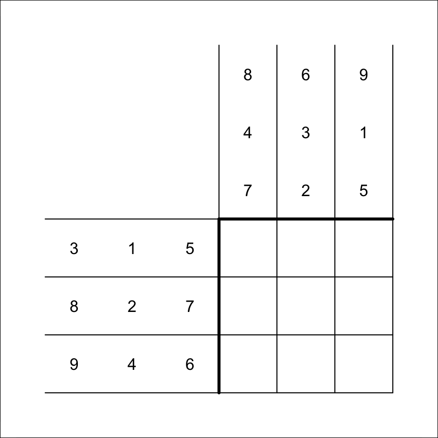

What is $c_{2,1}$?

To find $c_{2,1}$, you use row 2 from matrix $A$ and column 1 from matrix $B$.

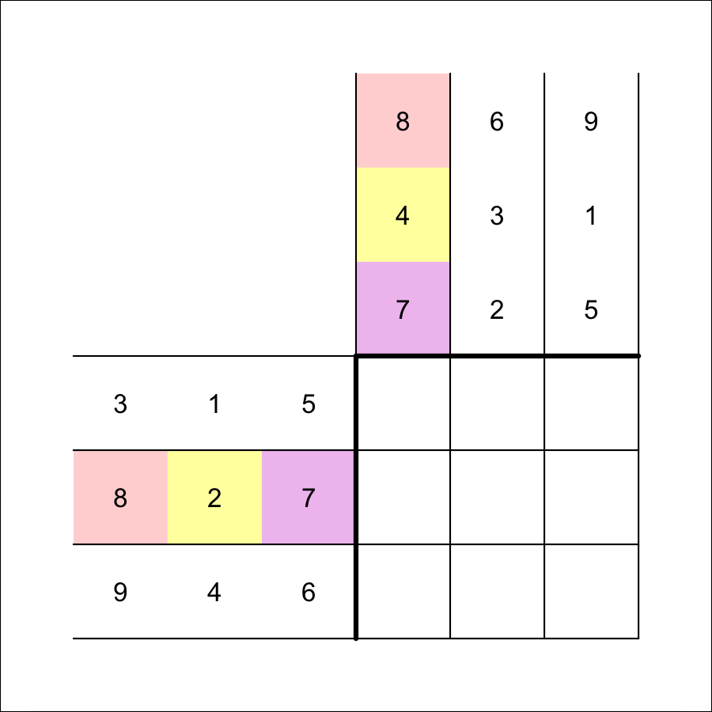

You multiply corresponding elements and sum those products.

$$c_{2,1}~=~( 8 \cdot 8 )+( 2 \cdot 4
)+( 7 \cdot 7 )$$

$$c_{2,1}~=~64+8+49$$

$$c_{2,1}~=~121$$

If you repeat this process for all 9 elements in $C$, you get:

$$\begin{bmatrix}
3 & 1 & 5\\
8 & 2 & 7\\
9 & 4 & 6
\end{bmatrix} \cdot \begin{bmatrix}
8 & 6 & 9\\
4 & 3 & 1\\
7 & 2 & 5
\end{bmatrix} ~=~ \begin{bmatrix}
63 & 31 & 53\\
121 & 68 & 109\\
130 & 78 & 115
\end{bmatrix}$$

Let matrices $A$ and $B$ be defined below.

$$A = \begin{bmatrix}
1 & 7 & 9\\
6 & 5 & 3\\
8 & 4 & 2
\end{bmatrix}$$
$$B = \begin{bmatrix}
2 & 3 & 6\\
5 & 9 & 8\\
4 & 1 & 7
\end{bmatrix}$$

A third matrix, $C$, is equal to the [product](https://en.wikipedia.org/wiki/Matrix_multiplication) $AB$. A student set up a diagram to help find the product:

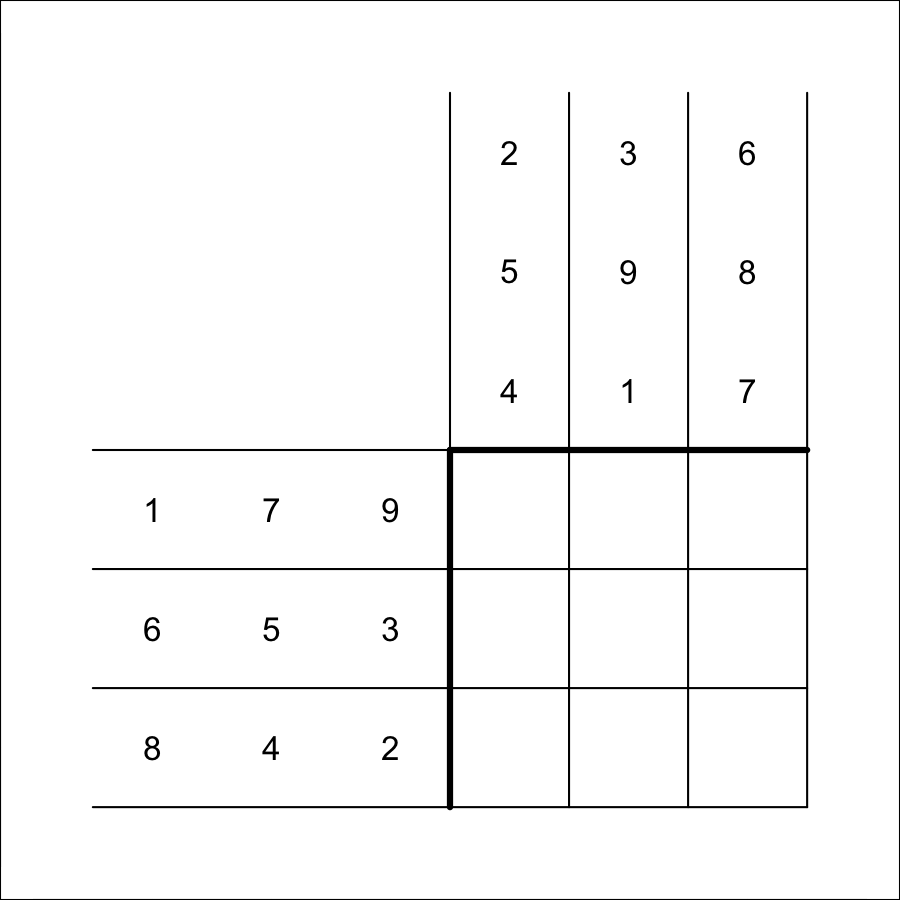

What is $c_{3,1}$?

To find $c_{3,1}$, you use row 3 from matrix $A$ and column 1 from matrix $B$.

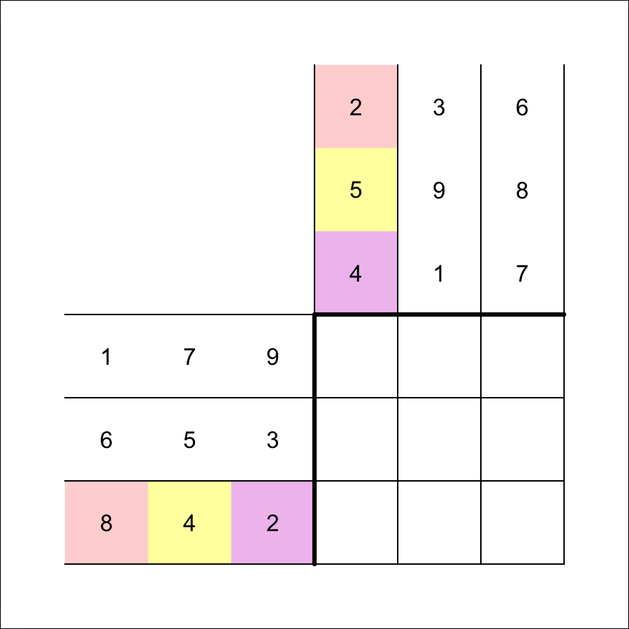

You multiply corresponding elements and sum those products.

$$c_{3,1}~=~( 8 \cdot 2 )+( 4 \cdot 5
)+( 2 \cdot 4 )$$

$$c_{3,1}~=~16+20+8$$

$$c_{3,1}~=~44$$

If you repeat this process for all 9 elements in $C$, you get:

$$\begin{bmatrix}
1 & 7 & 9\\
6 & 5 & 3\\
8 & 4 & 2
\end{bmatrix} \cdot \begin{bmatrix}
2 & 3 & 6\\
5 & 9 & 8\\
4 & 1 & 7
\end{bmatrix} ~=~ \begin{bmatrix}
73 & 75 & 125\\
49 & 66 & 97\\
44 & 62 & 94
\end{bmatrix}$$

Let matrices $A$ and $B$ be defined below.

$$A = \begin{bmatrix}
6 & 2 & 1\\
7 & 9 & 3\\
4 & 8 & 5
\end{bmatrix}$$
$$B = \begin{bmatrix}
8 & 4 & 9\\
2 & 7 & 6\\
5 & 1 & 3
\end{bmatrix}$$

A third matrix, $C$, is equal to the [product](https://en.wikipedia.org/wiki/Matrix_multiplication) $AB$. A student set up a diagram to help find the product:

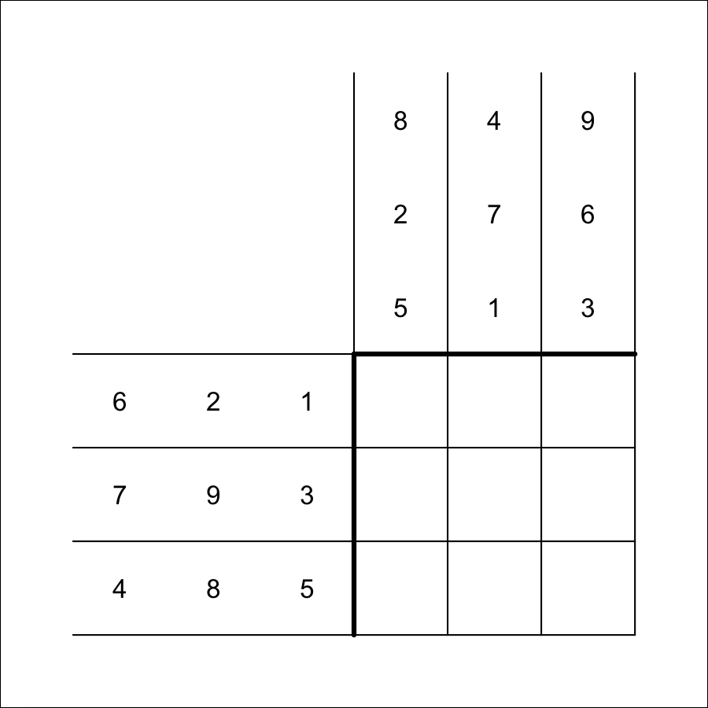

What is $c_{2,1}$?